# WHO Mortality Database: data harmonisation for the premature mortality project

2026-10-23

# About this page

This page documents how the WHO Mortality Database was harmonised and cleaned for the project *Premature mortality in successive birth cohorts across world regions*: the data used and the rules that select them (Section 1), then, step by step, the raw files read, the countries kept, ages, causes across ICD revisions, coding changes, ill-defined causes, gaps, peaks, population, and how countries were pooled into areas (Section 1.1). It is Section 1 of the project report (code/08_report.Rmd, rendered by code/08_render.R), built from the same sources, code/08_data.Rmd and code/08_who_processing.Rmd, so the two give the same text and numbers; only the links, the notes on them and the layout of the *Code:* lines differ. Every number is computed from the output files of the project when the page is rendered (code/16_docs.R).

The report itself is not published online, as its results are unpublished. Section, table and figure numbers are those of the report, and its other parts are cited as in the report, so that the two documents stay identical: Sections 2-8 and the figures other than D1 are in the report only. The analyses of the report are cited as Result 1 (cohort SDG 3.4 and the period-cohort gap, report Section 2), Result 2 (leading premature cause by cohort, report Section 3) and Result 3 (tobacco cohort lag, report Section 4); Module B is one of the replicated European analyses (premature-death shares by generation, report Section 5.1).

**Links.** The *Code:* lines that end each part of Section 1.1 and the code map (Table 1.8) point to the R code that does each step. For the scripts of the data build (`code/functions_pm.R`, `code/01_areas.R`, `code/02_cause_groups.R`, `code/03_who_deaths.R` and `code/04_area_series.R`), shown in full in the appendix, the line numbers open the code on this page with those lines highlighted; for the page’s own sources they open GitHub. File names link to the files of the public repository (filhoalm/premature-mortality-cohorts), which holds this first component of the project: the code of the data harmonisation and this page (docs/published.csv). Data, outputs and the scripts of the analyses are not published yet and are named without a link. The appendix also describes the columns of the two dictionaries that drive the build.

**Data and status.** Deaths and population: [WHO Mortality Database](https://www.who.int/data/data-collection-tools/who-mortality-database) (February 2026 release), with population completed from the [UN World Population Prospects](https://population.un.org/wpp/); the raw files are not redistributed. Work in progress: the numbers may change; please contact the author before citing or reusing them. Licence (LICENSE, to be confirmed): code MIT License, data outputs Creative Commons Attribution 4.0 International (CC BY 4.0); check the WHO Mortality Database terms of use before sharing derived data.

# 1 Data

**Source.** WHO Mortality Database, February 2026 release (raw files downloaded from cdn.who.int on 10 October 2026, Eu40_APC NOTES item 2): deaths by country, year, sex, age group and cause for ICD-7 to ICD-10, and WHO population (`mort_pop`), read without modification. Cause groups and their ICD-7 to ICD-10 codes are in `data/dict/who_cause_groups.csv`; NCD4 = cancer (C00-C97) + cardiovascular diseases (I00-I99) + diabetes (E10-E14) + chronic respiratory diseases (J30-J98). Person-years are the WHO population where it exists, completed by the population of the UN World Population Prospects (revision to be confirmed), estican data/UNDP/pop_UN.rds of 2 June 2026 (as used for GLOBOCAN 2024; read-only), calibrated to WHO by sex and age; see Population below.

**Areas and countries.** The 227 WHO country codes are mapped to ISO3 and to UN M49 numeric codes and names of the country, region, sub-region and intermediate region (`data/dict/areas.csv`; historical M49 codes for former entities); 136 are eligible (former entities, parts of countries, overlapping codes, codes without national data and countries rated Low by the WHO data-quality assessment are excluded). The data hold 6,669 country-years with deaths (161 codes, 1950-2024). The area- and country-level outputs carry the UN M49 codes next to the names (`region_code`, `area_code`; `m49_code` for countries), except `who_deaths.rds`, `who_checks.rds` and `list_transitions.csv` (WHO code only), `respiratory_checks.csv` (WHO code and ISO3) and `profiles.csv` (`area_code` only); `data/dict/areas.csv` links the WHO code to ISO3 and the M49 codes (NOTES item 87).

**WHO data-quality assessment.** The WHO assessment of the mortality data (estican `data/WHO_mortality_data_quality.csv`, read-only; NOTES item 85) rates each country by usability = completeness of death registration x (1 - the share of ill-defined or non-specific causes): 98 codes are rated: 60 High, 25 Medium and 13 Low. The 13 countries rated Low are not eligible: Andorra, Bahrain, Bulgaria, Egypt, El Salvador, Iraq, Lebanon, Malaysia, Maldives, Morocco, Oman, Peru and Qatar. Of the 53 area countries, 36 are rated High, 11 are rated Medium and 6 are not rated (Table 1.3). The rating is one recent assessment applied to every year, so the year-level ill-defined rule below is kept.

**Population.** Person-years are the WHO population (`mort_pop`, ages harmonised as the deaths, gaps of 1-3 years interpolated) where it exists. Every other cell (country, year, sex and age) of a country-year with deaths takes the UN WPP population times the WHO/WPP ratio of that sex and age, averaged over the 3 nearest WHO years on each side, held beyond the first or last WHO year and interpolated between two seams (‘WPP calibrated’), so that the series follows the WHO level and keeps the territory covered by the WHO deaths; countries without any WHO population take WPP as published (‘WPP’; NOTES item 84). Table 1.1 gives the source at ages 30-69. At the seams, the calibration ratio of the cells at 30-69 lies between 0.243 and 2.064 (median 0.997); 868 of 2,930 cells lie outside 0.9-1.1, 142 of 816 in the countries of the areas (`output/data_build/population_seams.csv`). The 3-year mean ratio, not the ratio of the WHO year next to the seam, is carried across the seam, so the series steps there by the deviation of that WHO year from the mean: with step = calibrated/WPP in the WPP year over WHO/WPP in the adjacent WHO year, minus 1 (ages 30-69, both sexes), |step| exceeds 2% at 5 of the 28 seams inside the area windows (Guatemala +4.2% (WHO 1984, WPP 1985), Costa Rica -3.6% (WHO 2019, WPP 2020), Philippines +3.3% (WHO 2004, WPP 2003), Puerto Rico -3.2% (WHO 1992, WPP 1993) and Philippines -2.8% (WHO 1994, WPP 1993)) and is at most 2.0% at the others.

Table 1.1. Country-years by source of the person-years at ages 30-69: WHO population, WHO interpolated over gaps of 1-3 years, UN WPP calibrated to WHO, UN WPP as published, mixed (some ages from each) or none (output/data_build/country_coverage.csv)

| Person-years at 30-69 | Country-years with deaths | Usable | In the area windows |
| --- | --- | --- | --- |
| WHO | 4,687 | 3,540 | 1,670 |
| WPP calibrated | 1,629 | 1,349 | 424 |
| WPP | 159 | 114 | 0 |
| WHO (interpolated) | 128 | 110 | 39 |
| none | 49 | 0 | 0 |
| mixed (WHO and WPP calibrated) | 17 | 12 | 0 |

**Usability rule** (Results 1-2). A country-year is usable when person-years and the deaths of every needed cause group are available at every age 30-69 for both sexes, the codes of the WHO List add up to the all-cause code, and ill-defined causes are at most 20% of deaths at 30-69. 5,125 of 6,669 country-years are usable, in 148 countries (Table 1.2). COPD is not part of the rule; the years where it is isolable are flagged (`copd_ok`) and used in Result 3 only.

**Windows.** A country’s usable series is its longest run of consecutive usable years, and the 96 eligible countries with at least 20 usable years are candidates. Each area is a UN M49 sub-region: among the windows of at least 25 years (or of the longest usable run of the candidates where that is shorter: Southern Asia, 22 years), the window and the candidates covering all of it with the largest person-years at 30-69; deaths and person-years are summed over these countries. 13 areas with 53 countries result (Table 1.3, Figure D1). Because the rule maximises person-years, a large country can shorten a window: leaving out one country would lengthen it by at least 10 years in Sub-Saharan Africa (without ZAF: MUS 1969-2024, 0.05 of the person-years), Eastern Asia (without KOR: HKG JPN 1969-2023, 0.98 of the person-years), South-eastern Asia (without PHL: SGP 1969-2022, 0.09 of the person-years) and Western Europe (without DEU: AUT BEL CHE FRA NLD 1969-2022, 0.84 of the person-years). The windows cover 2015 in 12 areas, not in Western Asia (ends 2007); the only alternative covering it is Western Asia ARM ISR KWT 1993-2023 (0.84 of the person-years), not used. Eastern Asia without Korea (HKG JPN 1969-2023, 0.98 of the person-years) starts 16 years earlier and is a supplementary area in Result 2.

Table 1.2. Country-years with deaths (1950-2024) by usability: usable or first failing criterion (output/data_build/country_coverage.csv)

| Status | Country-years | % |
| --- | --- | --- |
| usable | 5,125 | 76.8 |
| group not isolable | 1,232 | 18.5 |
| ill-defined > 20% | 239 | 3.6 |
| population missing | 49 | 0.7 |
| codes do not add up | 24 | 0.4 |

Table 1.3. Areas: UN M49 region and sub-region (numeric code), countries (WHO name, ISO3, UN M49 code, WHO data-quality rating) and windows; person-years, share of the person-years from UN WPP and deaths for both sexes over the window; base year 2015 (output/data_build/areas_included.csv, data/dict/areas.csv)

| Region | Area | Countries | Window | Years | Person-years 30-69 (millions) | WPP calibrated (%) | NCD4 deaths 30-69 (thousands) | Ill-defined 30-69 (%) | Covers base year |
| --- | --- | --- | --- | --- | --- | --- | --- | --- | --- |
| Africa (2) | Sub-Saharan Africa (202) | Mauritius (MUS 480, High), South Africa (ZAF 710, Medium) | 1994-2020 | 27 | 505.6 | 39.2 | 2,280 | 12.1 | yes |
| Americas (19) | Latin America and the Caribbean (419) | Argentina (ARG 32, Medium), Brazil (BRA 76, High), Chile (CHL 152, High), Colombia (COL 170, High), Costa Rica (CRI 188, High), Cuba (CUB 192, High), Ecuador (ECU 218, Medium), Guatemala (GTM 320, Med… | 1984-2023 | 40 | 6,838.4 | 86.3 | 21,094 | 5.9 | yes |
| Americas (19) | Northern America (21) | Canada (CAN 124, High), United States of America (USA 840, High) | 1969-2023 | 55 | 7,858.0 | 37.9 | 31,972 | 1.3 | yes |
| Asia (142) | Central Asia (143) | Kyrgyzstan (KGZ 417, High), Uzbekistan (UZB 860, High) | 1981-2023 | 43 | 462.1 | 0.0 | 2,138 | 1.5 | yes |
| Asia (142) | Eastern Asia (30) | Hong Kong SAR (HKG 344, not rated), Japan (JPN 392, Medium), Republic of Korea (KOR 410, High) | 1985-2023 | 39 | 3,660.6 | 0.0 | 9,338 | 2.4 | yes |
| Asia (142) | South-eastern Asia (35) | Philippines (PHL 608, High), Singapore (SGP 702, High) | 1992-2019 | 28 | 898.2 | 49.9 | 3,555 | 2.2 | yes |
| Asia (142) | Southern Asia (34) | Sri Lanka (LKA 144, not rated) | 1998-2019 | 22 | 197.1 | 74.6 | 609 | 8.2 | yes |
| Asia (142) | Western Asia (145) | Armenia (ARM 51, High), Azerbaijan (AZE 31, not rated), Georgia (GEO 268, Medium), Israel (ISR 376, Medium) | 1981-2007 | 27 | 231.2 | 0.0 | 1,120 | 3.1 | no |
| Europe (150) | Eastern Europe (151) | Belarus (BLR 112, High), Hungary (HUN 348, High), Republic of Moldova (MDA 498, High), Poland (POL 616, Medium), Romania (ROU 642, High), Russian Federation (RUS 643, not rated), Ukraine (UKR 804, not… | 1981-2018 | 38 | 5,312.4 | 0.0 | 39,108 | 2.6 | yes |
| Europe (150) | Northern Europe (154) | Denmark (DNK 208, High), Finland (FIN 246, High), United Kingdom (GBR 826, High), Ireland (IRL 372, High), Norway (NOR 578, High), Sweden (SWE 752, High) | 1969-2022 | 54 | 2,300.1 | 0.1 | 10,013 | 0.9 | yes |
| Europe (150) | Southern Europe (39) | Spain (ESP 724, High), Greece (GRC 300, Medium), Italy (ITA 380, High), Malta (MLT 470, High) | 1968-2022 | 55 | 3,028.0 | 0.0 | 10,496 | 1.7 | yes |
| Europe (150) | Western Europe (155) | Austria (AUT 40, High), Belgium (BEL 56, High), Switzerland (CHE 756, High), Germany (DEU 276, High), France (FRA 250, Medium), Luxembourg (LUX 442, High), Netherlands (NLD 528, High) | 1989-2020 | 32 | 3,111.6 | 0.2 | 9,896 | 4.7 | yes |
| Oceania (9) | Australia and New Zealand (53) | Australia (AUS 36, High), New Zealand (NZL 554, High) | 1968-2020 | 53 | 545.4 | 0.0 | 1,864 | 0.5 | yes |

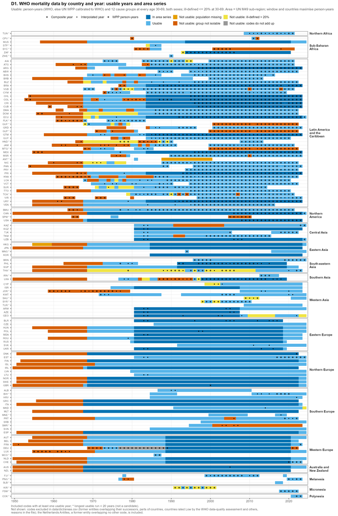

Figure D1. Usable years and area series by country (output/data_build/figures/D1_coverage.png; PDF alongside).

**Data caveats.**

- 304 country-years are interpolated across gaps of 1-3 years and 22 are composites (Germany before 1990 = FRG + GDR; United Kingdom 2000 = its parts); both count as usable and are marked in D1, as are the years with WPP person-years.
- Territory changes inside windows: MUS 2018 (person-years 30-69 vs 2017: country +3.3%, area +4.2%); GEO 1994 (person-years 30-69 vs 1992: country -9.0%, area +1.2%); MDA 1997 (person-years 30-69 vs 1996: country -16.2%, area -0.7%); RUS 1993 (person-years 30-69 vs 1992: country +0.1%, area +0.1%); RUS 2004 (person-years 30-69 vs 2003: country +0.6%, area +0.5%); UKR 2014 (person-years 30-69 vs 2012: country -3.2%, area +0.7%). Deaths and population refer to the same territory, so rates stay consistent; none of these changes falls in WPP years.
- Ill-defined causes are 0.5% (Australia and New Zealand) to 12.1% (Sub-Saharan Africa) of deaths at 30-69 over the windows and are not redistributed.
- COPD (J40-J47) is isolable only in some WHO Lists (`copd_ok` years); where too few such years remain, the COPD lag is not assessable (Section 4).

## 1.1 How the WHO Mortality Database was processed

This section explains, step by step, what was done to the WHO data before any analysis, what was deliberately left as reported, and why. Each part starts with a short summary in plain words, followed by the exact rule and, where relevant, what was not done, and ends with links to the R code that does the step and to the files that hold the details. File names open the files in the GitHub repository (main branch), for readers with access to it. The line numbers of the data-build scripts open their code in the appendix of this page, the others the script on GitHub at those lines; they are read from the scripts each time this page is rendered. The `.rds` files (R data, read with `readRDS()`) are not in the repository (rebuilt by the scripts); their columns are described in data/derived/dictionary.csv.

**Terms used here.**

- *ICD*: International Classification of Diseases, revisions 7 to 10.
- *List*: a WHO cause list, the set of codes a country used in a year, for example 104 = ICD-10 at four characters (Table 1.5).
- *NCD4*: cancer, cardiovascular diseases, diabetes and chronic respiratory diseases, the four groups of SDG target 3.4.
- *F1*: the period SDG 3.4 indicator, the probability of dying from NCD4 between 30 and 70 at the death rates of one calendar year (Figure F1, Section 2).
- *Usable year*: a country-year that passes the usability rule: every needed cause group can be separated at every age 30-69, the population is known, WHO’s chapter totals add up to its all-cause total, and ill-defined causes are at most 20% of deaths at 30-69.
- *Window*: the years over which an area is followed, with the same countries in every year.
- *Composite*: a series built by adding up its parts (Germany 1969-1989 and United Kingdom 2000).
- *WPP calibrated*: UN World Population Prospects population, scaled to the WHO population by sex and age.
- *Study sub-project* (`Study/`): the repetition of Bray et al. 2021 (premature NCD deaths, 2000-2019) for the same areas; its sensitivity analysis *F8* redistributes ill-defined deaths.
- *Eu40_APC*: the sister project on European generations, whose raw WHO files and methods are reused here. It is a separate project: its files, the raw WHO files among them, are not in this repository; the WHO files can be downloaded from the WHO Mortality Database.

### In brief

- **The raw data.** The WHO Mortality Database (February 2026 release) gives the deaths registered in each country by year, sex, age group and cause, coded with ICD-7 to ICD-10 in 12 WHO cause lists, together with WHO population figures. The raw files were only read, never edited: every step below is done in R and writes new files.
- **What was changed.** Ages were put into the same 18 five-year groups, deaths of unknown age were shared out over the ages pro rata within each cause group, and gaps of 1-3 years were filled with a straight line. Two series were completed from their parts (Germany 1969-1989 and United Kingdom 2000), and missing population was taken from the UN World Population Prospects (WPP), adjusted to the WHO level.
- **What was not changed: ill-defined causes.** Deaths certified only with a symptom or an unknown cause (ICD-10 R00-R99 and the matching codes of earlier revisions) stay a group of their own and were **not** shared out among the other causes, pro rata or otherwise; years where they exceed 20% of deaths at 30-69 are not used. A pro-rata redistribution was tested only in a sensitivity analysis of the Study sub-project (F8), for the 2000-2019 change of the period NCD4 indicator (largest effect in Southern Asia: -8.0% as certified, -18.1% redistributed); its effect on Results 1-3 was not computed (Table 1.6).
- **Other things left as reported.** Deaths of unknown sex were dropped, age groups merged by a country (for example 75 and over) were left missing, and the WHO population was used as published. Changes of WHO cause list were flagged, not corrected.
- **What was kept.** Only national data, one code per territory and no country rated Low by WHO; a year is used only if every needed cause group can be separated at 30-69, the population is known, WHO’s chapter totals add up to its all-cause total and ill-defined causes are at most 20%. Each area sums a fixed set of countries over a fixed window, each country contributing its longest unbroken run of such years (Table 1.4).
- **Gaps.** Only runs of 1-3 missing years were filled; longer gaps break a country’s series. Filled years are 55 of the 2,133 country-years in the area windows (1.4% of the person-years at 30-69).
- **Peaks.** No year was removed, smoothed or corrected because of a peak. All 85 year-to-year changes of at least 1 percentage point in F1 (the period SDG 3.4 indicator: the probability of dying from NCD4 between 30 and 70 at one calendar year’s death rates) are in Table 1.7 with a verdict: some are real events (crises, a disaster, COVID-19), some come from the data (a change of cause list, filled years, a step in the population), and some are not explained.
- **Where to check.** Each part below ends with links to the R code, Table 1.8 maps every step to its code, and the decisions are numbered in NOTES.md.

**From the WHO files to the area series.** Table 1.4 follows the country-years through the build. The build applies the usability rule to every code and eligibility afterwards; the counts below do not depend on the order. Table 1.2 counts the usable years of all codes, eligible or not (5,125); here only eligible codes are counted, from ‘Eligible codes’ on.

Table 1.4. Data flow: WHO country codes and country-years at each step of the data build, from the national deaths in the WHO files to the area windows (data/dict/areas.csv, output/data_build/country_coverage.csv, output/data_build/areas_included.csv)

| Step | What is kept | Countries (WHO codes) | Country-years | Change at this step |
| --- | --- | --- | --- | --- |
| WHO files | Country-years with national deaths in the WHO files | 161 | 6,344 | Not used: 66 codes without national rows (4 of them with regional rows only: Bangladesh, China, Occupied Palestinian Territory and Pakistan) |
| Gaps filled | Plus missing years: gaps of 1-3 years filled and composite years (Germany 1969-1989 and United Kingdom 2000) | 161 | 6,669 | Added: 303 filled years and 22 composite years |
| Eligible codes | One code per territory; countries rated Low by WHO left out | 136 | 5,877 | Left out: rated Low by WHO 374 (13 codes), parts of countries 272 (6 codes) and former entities 146 (6 codes) |
| Usable years | Every needed cause group at every age 30-69, population known, WHO chapter totals equal to the all-cause total (‘codes add up’), ill-defined at most 20% | 126 | 4,606 | Left out: group not isolable 1,071, ill-defined > 20% 159, population missing 29 and codes do not add up 12 |
| Long series | Each country’s longest unbroken run of usable years, if at least 20 years | 96 | 4,068 | Left out: 254 years of the 30 countries with shorter runs and 284 usable years outside the longest run |
| Area windows | Years inside the window of the country’s area (13 areas) | 53 | 2,133 | Left out: 1,449 years of the 43 candidates whose run does not cover their area’s window and 486 years outside the window |

### Raw files

*In plain words.* Everything starts from the raw files of the WHO Mortality Database. They were downloaded once for the sister project Eu40_APC and are kept there in a read-only folder. There is one file of deaths per ICD revision (ICD-10 in several parts), two Excel workbooks for recent years of Germany and Norway, the population file, the list of country codes and WHO’s notes. Only national rows are used: rows for a region, a city or a population group are skipped.

*Exact rule.*

- Source: WHO Mortality Database, February 2026 release (raw files downloaded from cdn.who.int on 10 October 2026, Eu40_APC NOTES item 2). Deaths: 9 files (MortIcd7, Morticd8, Morticd9, Morticd10_part1, Morticd10_part2, Morticd10_part3, Morticd10_part4, Morticd10_part5 and Morticd10_part6) and the workbooks Germany.xlsx and Norway.xlsx; population `mort_pop`, codes `mort_country_codes` and notes `mort_notes`, all in `Eu40_APC/data/who_mortality/raw/`. The documentation PDF (`raw/mort_documentation/`) is cited by page in the cause dictionary. `mort_availability` is not read: the years come from the rows themselves (NOTES items 2 and 32).
- National rows are those with `Admin1` and `SubDiv` blank. The national extract is cached and rebuilt whenever a raw file changes.
- The Norway workbook (2017-2024) merges ages 0-14, which are left missing; ages 30-69 are complete, so these years are used. The Germany workbook (2021-2022) suppresses small cells, so only all-cause deaths are taken from it and these years are not usable (NOTES items 16-17).

*Code:*

- code/functions_pm.R: raw files and release (`who_raw`, `who_src`, `who_files`, `who_xl`), lines 7-10
- code/03_who_deaths.R: national rows only, `keep()`, lines 55-59; raw files read once and cached, lines 60-67
- code/01_areas.R: years with national and regional rows per code, lines 53-62
- Details: data/dict/areas.csv

### Countries and data quality

*In plain words.* WHO uses its own country codes. Each code was given its ISO3 code and the UN M49 codes and names of its country, region and sub-region; the sub-region is the ‘area’ of this study. Some codes describe the same people twice: a country and its parts, or a former state and its successors. One code per territory is kept: the United Kingdom rather than its parts, unified Germany, and the successor states rather than the USSR, Czechoslovakia or Yugoslavia. Codes with regional data only are not used, and neither are countries rated Low in WHO’s own assessment of data quality. Two series were completed by adding up their parts. Changes of territory inside a series were documented but not adjusted, because the WHO deaths and the WHO population of a year cover the same territory.

*Exact rule.*

- 227 WHO codes. ISO3 comes from the name (countrycode package), set by hand for former entities and parts of countries; the regions of 15 codes not in M49 were set by hand (NOTES items 4-5).
- 136 codes are eligible and 91 are not (reasons in `data/dict/areas.csv`; NOTES item 6). 66 have no national rows: 61 have no rows at all, 4 have regional rows only (Bangladesh, China, Occupied Palestinian Territory and Pakistan) and 1 is a former entity without data (Sudan, Former). Of the codes with national rows, 25 are left out: 13 rated Low by WHO, 6 parts of countries and 6 former entities (Table 1.4). Regional rows, which 13 codes have, are never used.
- WHO data-quality rating (above): of the eligible codes, 59 are rated High and 25 Medium, 47 are not in the WHO assessment and 5 are in it without a rating (Russian Federation, Seychelles, Solomon Islands, Turkmenistan and Ukraine; NOTES item 85).
- Composites: deaths and person-years of the parts are added by year, sex, age and cause group (Germany 1969-1989 = 4100 + 4090 and United Kingdom 2000 = 4310 + 4320 + 4330, WHO codes; NOTES item 7).
- Territory changes in 6 codes (Mauritius 2018, Japan 1972, Georgia 1994, Republic of Moldova 1997, Russian Federation 1993 and 2004 and Ukraine 2014) were not adjusted; their effect on the person-years inside the windows is in the Data caveats above (NOTES items 7 and 28).

*Not done.* The WHO rating is one recent assessment applied to every year: completeness of registration in earlier decades was not assessed or corrected, and no data were weighted by quality (NOTES item 85, Section 7).

*Code:*

- code/01_areas.R: WHO codes to ISO3 and UN M49, lines 15-44; WHO data-quality rating, lines 48-50; years filled by composites, lines 70-71; eligibility (`include`, `reason`), lines 75-92; territory changes, lines 97-110
- code/03_who_deaths.R: composites: parts added, lines 192-202
- Details: data/dict/areas.csv

### Ages

*In plain words.* Countries report deaths in different age layouts. Some give every five-year group up to 95 and over; others merge the old ages (for example 75 and over) or give no ages at all. All layouts were turned into the same 18 five-year groups, from 0-4 to 85 and over. When a country merged ages across these groups, the merged cells were left missing rather than split by assumption. Deaths of unknown age were shared out over the ages in proportion to the deaths of known age of the same cause group, in the same country, year and sex: each group keeps its age pattern and its number of deaths. Deaths of unknown sex were dropped.

*Exact rule.*

- `age18()` adds the WHO age columns into 18 groups according to each row’s age format (the WHO variable `Frmat`; WHO documentation, Annex 1, PDF p.8). Formats 03 and 04 (75 and over merged), 05 (70 and over) and 06 (65 and over) leave the merged groups missing; 07 and 08 (ten-year groups) and 09 (no ages) leave every age missing; the Norway workbook leaves ages 0-14 missing.
- Observed country-years by age format (6,344 in all):
  - every age (formats 00-02): 5,996;
  - ages from 70 or 75 on merged (formats 03-05): 81, of which 54 usable, since ages 30-69 are complete;
  - ages below 70 merged, or no ages (formats 06-09): 259, of which 0 usable;
  - the Norway workbook (ages 0-14 merged): 8, of which 8 usable.
- In the area windows, old ages are merged in 5 country-years (CRI 1984; KOR 1995-1996; LKA 2015, 2019) and ages 0-14 in 6 (NOR 2017-2022). The area cells concerned are then missing. Later analyses fill them over 1-3 years (Eastern Asia 1995-1996, ages 75-84) or drop such years at a window end (Latin America and the Caribbean 1984; Southern Asia 2015-2019; Section 6, ‘Projections’).
- Unknown age (WHO column 26, deaths of unknown age): at every age, the deaths of a group are multiplied by 1 + unknown/known, separately by country, year, sex and cause group; a group with deaths of unknown age only is left missing. All causes by age is then rebuilt as the sum of the six exclusive groups (below), so its age pattern follows the cause mix (NOTES item 16).
- Unknown sex (WHO sex code 9): dropped, a very small number of deaths (NOTES item 16). The WHO population of unknown age is dropped as well (NOTES item 18).

*Not done.* Merged age groups were not split or modelled in the data build. The numbers of deaths of unknown age are not saved in any output file, so their size is not reported here (those of unknown sex are in NOTES item 16).

*Code:*

- code/functions_pm.R: `age18()`: WHO age formats to 18 groups, merged groups missing, lines 24-31
- code/03_who_deaths.R: unknown sex dropped, line 73; unknown age shared out within each group, line 112; all causes by age = sum of the exclusive groups, lines 120-122
- Details: data/derived/who_deaths.rds (R data, not in the repository)

### Causes across ICD revisions

*In plain words.* Between 1950 and 2024 countries coded deaths with the 7th to 10th ICD revisions and, within each, with condensed or detailed WHO cause lists (Table 1.5). One dictionary, `data/dict/who_cause_groups.csv`, says which codes of each list make up each cause group, with the page of the WHO documentation for every row. Six groups never overlap and add up to all causes: cancer, cardiovascular diseases, external causes, ill-defined causes, COVID-19 and ‘other’ (everything else). NCD4, the group of SDG 3.4, is cancer + cardiovascular diseases + diabetes + chronic respiratory diseases. When a list has no code for a group (for example ischaemic heart disease in ICD-7), the group is left missing, not estimated, and the year cannot be used for Results 1-2: no ICD-7 year is usable, so none is in the area windows.

*Code:*

- code/02_cause_groups.R: cause-group dictionary, lines 11-57
- code/03_who_deaths.R: code ranges expanded, `expand()`, lines 37-50; groups by age, missing groups, ‘other’, NCD4: `chunk()`, lines 72-132; all-cause code checked against the documentation, lines 148-153; checks: six groups add up (by construction), chapter codes add up to the all-cause code, ‘other’ not negative, lines 221-248; codes shared by two groups, lines 267-290
- code/04_area_series.R: sub-groups capped at their parent group (IHD and stroke scaled together), lines 39-48; COPD flag `copd_ok`, line 52
- Details: data/dict/who_cause_groups.csv, data/derived/who_checks.rds (R data, not in the repository), output/data_build/group_overlap.csv

Table 1.5. WHO cause lists in the national rows: years, WHO country codes and observed country-years (all, of eligible codes, and usable), and the needed groups with no code in the list, which are therefore missing (data/dict/who_cause_groups.csv; WHO documentation, PDF p.9-10). A group can also be missing in a year when a required sub-item is not reported (e.g. COPD in most 09A years)

| List | Cause list | Years | Countries (WHO codes) | Country-years All | Country-years Eligible codes | Country-years Usable | No code for |
| --- | --- | --- | --- | --- | --- | --- | --- |
| 07A | ICD-7, List A | 1950-1972 | 71 | 790 | 649 | 0 | IHD, chronic respiratory diseases and COPD |
| 07B | ICD-7, List B | 1954-1970 | 21 | 110 | 96 | 0 | lung cancer, IHD, chronic respiratory diseases and COPD |
| 08A | ICD-8, List A | 1968-1994 | 89 | 809 | 697 | 606 |  |
| 08B | ICD-8, List B | 1969-1979 | 10 | 28 | 23 | 0 | lung cancer and chronic respiratory diseases |
| 09A | ICD-9, Basic Tabulation List | 1979-1999 | 45 | 553 | 527 | 488 |  |
| 09B | ICD-9, Basic Tabulation List | 1979-2013 | 76 | 925 | 777 | 725 |  |
| 09N | ICD-9, special list of former USSR states | 1980-2005 | 16 | 248 | 239 | 239 |  |
| 101 | ICD-10, Mortality Tabulation List 1 | 1996-2023 | 14 | 157 | 146 | 103 |  |
| 103 | ICD-10, 3 characters | 1994-2024 | 41 | 397 | 300 | 289 |  |
| 104 | ICD-10, 4 characters | 1988-2024 | 124 | 2,319 | 2,122 | 1,963 |  |
| 10M | ICD-10, 3 and 4 characters | 1996-1999 | 2 | 6 | 6 | 6 |  |
| UE1 | ICD-10, special list for Portugal | 2004-2005 | 1 | 2 | 2 | 0 | lung cancer and chronic respiratory diseases |

### Coding changes

*In plain words.* When a country moves to another ICD revision or WHO list, a cause’s share of deaths can jump only because codes are grouped differently. For every such change, the last year of the old list was compared with the first year of the new one, and a relative change of more than 15% in a group’s share of deaths at 30-69 was flagged (for example, a share of 20% becoming more than 23% or less than 17%). The flags are warnings: no data were corrected, no year was excluded and the windows were not chosen to avoid them.

*Exact rule.*

- 390 changes in 138 codes, 360 of them assessable at 30-69 (observed years only). Flagged, of the assessable changes: NCD4: 23 of 248 flagged, median change 2.1%; lung cancer: 81 of 309 flagged, median change 6.2%; COPD: 69 of 185 flagged, median change 10.4%; IHD: 74 of 264 flagged, median change 6.0%; diabetes: 151 of 356 flagged, median change 12.0%; chronic respiratory diseases: 101 of 244 flagged, median change 10.5%; stroke: 101 of 360 flagged, median change 6.6%; cancer: 53 of 360 flagged, median change 3.8%; cardiovascular diseases: 53 of 360 flagged, median change 3.5% (`output/data_build/list_transitions.csv`; NOTES item 15). 89 comparisons span more than one year, so they also contain the trend between the two years.
- Inside the area windows there are 86 changes, at least one in each of the 53 countries; 43 of these 86 changes have no flag in any of the nine groups of Results 1-3. NCD4 is flagged at 1 of them: Sri Lanka 103 to 104, 2005-2006, +25% (`output/data_build/window_transitions.csv`; NOTES item 31; Section 7, ‘List changes’).
- Two known steps were handled by the choice of codes in the dictionary instead (Causes above): ICD-7 cardiovascular diseases include cerebrovascular disease, and the former-Soviet COPD definition was checked at its List changes and kept as an approximation (NOTES item 12).

*Not done.* No bridge coding or comparability ratios were applied, flagged years were not excluded, and there is no run without them. The Study sub-project gives, for its country sets, the implied effect of each flagged change on an area’s deaths from each cause (`lt_effect` in Study/output/replication/probability.csv): at least 5% for 10 area-cause pairs, in Sub-Saharan Africa, Central Asia, South-eastern Asia, Southern Asia and Western Asia (Study NOTES item 7).

*Code:*

- code/03_who_deaths.R: List transitions, 15% rule, lines 250-265
- code/04_area_series.R: transitions inside the area windows, lines 117-120
- Details: output/data_build/list_transitions.csv, output/data_build/window_transitions.csv

### Ill-defined causes

*In plain words.* Some deaths are certified only with a symptom or as ‘cause unknown’: ICD-10 chapter R and the matching chapter of earlier revisions. These ill-defined deaths are a cause group of their own. They count in all causes, and so in the competing mortality (deaths from other causes) of Result 1, but never in cancer, cardiovascular diseases or NCD4. They were **not** redistributed, pro rata or by any other rule, in the data or in Results 1-3.

*Why not.* The analyses use deaths as certified, the method copied from Eu40_APC. Sharing them out pro rata would assume that ill-defined deaths have the same mix of causes as the certified deaths of the same area, sex, year and age, which the WHO files cannot confirm. Two steps deal with them instead: a year is not used when more than 20% of its deaths at 30-69 are ill-defined, and a sensitivity analysis measures what a redistribution would change (Table 1.6). Where the share is high, NCD4 rates are probably too low, since some ill-defined deaths are likely NCD4 deaths. Where the share changes, NCD4 trends are biased: a falling share (it fell most in Southern Asia and Latin America and the Caribbean) understates NCD4 declines, a rising share (it rose most in Western Europe and Western Asia) overstates them.

*Does it matter?* For trends, little in most areas: in the Study’s sensitivity analysis F8 (2000-2019, both sexes), redistribution moves the % change of the NCD4 probability by a median of 1.0 percentage points over the 13 areas, and by more than 5 points only in Southern Asia (-8.0% becomes -18.1%). For levels, the NCD4 probability in 2000 would be 0.3% (Australia and New Zealand) to 19.9% (Southern Asia) higher, and more than 5% higher in Southern Asia (19.9%), Sub-Saharan Africa (12.0%) and Latin America and the Caribbean (8.3%) (last column of Table 1.6). Results 1-3 were not re-run with redistributed deaths.

*Exact rule.*

- Definition (`ill_defined` rows of the dictionary): ICD-7 780-795, ICD-8 780-796, ICD-9 780-799 and ICD-10 R00-R99. Other vague codes, such as heart failure or cancer of unspecified site, stay in their own groups.
- Share of deaths at 30-69 over the windows: 0.5% (Australia and New Zealand) to 12.1% (Sub-Saharan Africa); first and last year of each window in Table 1.6.
- Limit `ill_max` = 20% of deaths at 30-69, both sexes: 239 country-years are not usable for this reason (159 of eligible codes; most in Thailand 39, Honduras 16, Oman 16 and Dominican Republic 14). In 2 area countries the year just before the window fails the limit (Sri Lanka 1997, 20.2% and South Africa 1993, 20.4%); their usable runs, and so the windows of Southern Asia and Sub-Saharan Africa, start the year after.
- In the area windows, ill-defined causes are above 5% of deaths at 30-69 in 411 of 2,133 country-years, above 10% in 94 and above 15% in 8 (highest Sri Lanka 1998, 18.8%).
- Study sensitivity analysis F8: in each area, sex, year and age group at 30-69, each NCD4 cause is multiplied by (all - external - COVID-19) / (all - external - COVID-19 - ill-defined), which shares the ill-defined deaths out pro rata among all causes except external causes and COVID-19; years 2000-2019, both sexes, the Study’s country sets (as here except Western Asia: ARM ISR KWT and Eastern Europe: CZE HUN MDA POL ROU RUS SVK UKR; Table 1.6; Study NOTES item 1).
- Module B (premature-death shares, Section 5.1) also writes a ‘redistributed’ variant to its CSV files: ill-defined deaths shared out in proportion to the other five groups. This raises every other share of a 5-year birth-cohort group by the same factor, 1 / (1 - ill-defined share): at 40-59 by a median of 1.6% and at most 14.0% (cohort groups observed at every age of the window). As the factor is the same for every cause, it cannot change the leading cause; the report shows the observed shares (and the variant without 2020-2022), not the redistributed ones.

*Not done.* The effect of a redistribution on Results 1-3 (cohort probabilities, crossing cohorts, lags) was not computed. No run with another ill-defined limit was made (`04_area_series.R` accepts `ill_max=` for such runs). Vague codes outside chapter R were not reassigned (Study NOTES item 1).

*Code:*

- code/03_who_deaths.R: `ill_defined`, one of the exclusive groups, line 29; ill-defined share at 30-69, lines 241-242
- code/04_area_series.R: limit `ill_max`, line 22; ill-defined criterion of the usability rule, line 58
- code/09_shares_generation.R: Module B ‘redistributed’ variant (CSV only), lines 63-64
- Study/code/02_replication.R: F8, ill-defined deaths redistributed pro rata, lines 43-46
- Details: data/derived/who_checks.rds (R data, not in the repository), output/data_build/country_coverage.csv, output/shares_world/shares_cohort.csv, Study/output/replication/sensitivity.csv

Table 1.6. Ill-defined causes by area: share of deaths at ages 30-69 (both sexes) over the window, in its first and last year and at its highest; Study sensitivity analysis F8: % change in the NCD4 probability of dying between 30 and 70 (both sexes) over 2000-2019 with deaths as certified (main analysis) and with ill-defined deaths redistributed pro rata, and how much higher the 2000 level is when redistributed. F8 uses the Study’s country sets, which differ from the areas here for Western Asia (ARM ISR KWT; window here 1981-2007) and Eastern Europe (CZE HUN MDA POL ROU RUS SVK UKR; window here 1981-2018) (data/derived/area_series.rds, output/data_build/areas_included.csv, Study/output/replication/sensitivity.csv)

| Area | Window (years) | Ill-defined, % of deaths at 30-69 Whole window (%) | Ill-defined, % of deaths at 30-69 First year | Ill-defined, % of deaths at 30-69 Last year | Ill-defined, % of deaths at 30-69 Highest (year) | Study F8 (Study country sets): NCD4 probability of dying 30-70 % change 2000-2019, as certified | Study F8 (Study country sets): NCD4 probability of dying 30-70 % change 2000-2019, redistributed | Study F8 (Study country sets): NCD4 probability of dying 30-70 Level in 2000, redistributed vs certified (+%) |
| --- | --- | --- | --- | --- | --- | --- | --- | --- |
| Sub-Saharan Africa | 1994-2020 | 12.1 | 14.6 | 14.5 | 15.4 (1995) | -18.9 | -16.3 | 12.0 |
| Latin America and the Caribbean | 1984-2023 | 5.9 | 10.1 | 3.8 | 10.1 (1984) | -19.3 | -22.4 | 8.3 |
| Northern America | 1969-2023 | 1.3 | 1.5 | 2.1 | 2.1 (2023) | -27.5 | -27.0 | 1.2 |
| Central Asia | 1981-2023 | 1.5 | 2.1 | 1.3 | 2.4 (1996) | -27.7 | -27.5 | 1.0 |
| Eastern Asia | 1985-2023 | 2.4 | 2.1 | 5.8 | 5.8 (2023) | -37.8 | -35.6 | 1.6 |
| South-eastern Asia | 1992-2019 | 2.2 | 3.4 | 2.4 | 4.9 (1999) | 3.5 | 3.6 | 2.1 |
| Southern Asia | 1998-2019 | 8.2 | 18.8 | 5.7 | 18.8 (1998) | -8.0 | -18.1 | 19.9 |
| Western Asia | 1981-2007 | 3.1 | 3.4 | 7.8 | 7.8 (2007) | -37.2 | -35.2 | 2.6 |
| Eastern Europe | 1981-2018 | 2.6 | 1.8 | 3.6 | 5.6 (1984) | -33.4 | -32.3 | 2.1 |
| Northern Europe | 1969-2022 | 0.9 | 0.4 | 1.9 | 1.9 (2022) | -36.7 | -36.2 | 0.8 |
| Southern Europe | 1968-2022 | 1.7 | 2.1 | 3.0 | 3.1 (2019) | -32.3 | -31.3 | 1.6 |
| Western Europe | 1989-2020 | 4.7 | 3.2 | 7.7 | 8.3 (2019) | -32.7 | -29.3 | 3.8 |
| Australia and New Zealand | 1968-2020 | 0.5 | 0.3 | 1.4 | 1.9 (1995) | -32.5 | -31.7 | 0.3 |

### Gaps and interpolation

*In plain words.* Some countries skip one or a few years. Where 1-3 years in a row are missing inside a series, the deaths of every cause group, sex and age were filled with a straight line between the year before and the year after the gap; the WHO population was filled in the same way. Filled years count as usable and are marked (points in Figure D1). Longer gaps were not filled: they break a country’s series, and only its longest unbroken run is used.

*Exact rule.*

- `interp()`: value = value before + (year - year before) / (year after - year before) x (value after - value before), on counts (deaths, person-years), not on rates; deaths and population are filled separately.
- Deaths: 303 country-years in 87 codes, in runs of one year (100), two (73) and three (19); with the composite Germany 1979, which has a filled part, 304 (Data caveats). WHO population: 128 country-years at 30-69 (Table 1.1). Not filled: 54 gaps of 4 years or more (532 missing country-years in 45 codes).
- In the area windows: 55 of 2,133 country-years in 15 countries, 1.4% of the person-years at 30-69. At least one country is filled in 43 of 513 area-years, and every country of the area in Central Asia 1983-1984 and Southern Asia 2008, 2016-2018.
- A gap that spans a change of List spreads the coding step evenly over the filled years (List label ‘old/new’).
- Known issue: the filling also applies to COVID-19. Puerto Rico 2018-2020 is filled between 2017 and 2021, so 1,093 COVID-19 deaths appear in 2018 and 2019, at most 0.023% of the deaths of Latin America and the Caribbean in a year (to be fixed at the next rebuild, NOTES item 92; Section 7). COVID-19 is not part of NCD4, so F1 and the NCD4 results are not affected; these deaths count only in all causes.

*Not done.* Gaps longer than 3 years were not filled, and no model-based or rate-based filling was used.

*Code:*

- code/functions_pm.R: `gaps()`, lines 34-39; `interp()`, lines 40-47
- code/03_who_deaths.R: deaths of every group interpolated, lines 160-168; WHO population interpolated, line 174
- code/04_area_series.R: interpolated years count as usable, flagged, lines 63-65
- code/07_tobacco_lag.R: missing area cells interpolated before a model fit (also scripts 11-13), line 31
- Details: output/data_build/country_coverage.csv

### Peaks

*In plain words.* A peak in a series can be real (an epidemic, a crisis, a disaster) or come from the data (a change of cause list, a filled year, a step in the population). The build never removes, smooths or corrects a year because of a peak. It prevents some artefacts by design: each area keeps the same countries over its whole window, so countries entering or leaving cannot create a jump, and country-years that fail the usability rule are left out. It flags or records the rest: changes of cause list, filled and composite years, the source of the population and changes of territory.

For this section, every year-to-year change of at least 1 percentage point in F1 was listed: 85 of the 1,000 changes (13 areas, 2 sexes, every year of the windows), in 11 areas, most in Central Asia and Eastern Europe. In 6 areas one country holds more than 80% of the person-years (From countries to areas, below), so a peak of the area is a peak of that country. Table 1.7 groups the changes into episodes and traces each to the countries and causes behind it and to the build’s flags; the 23 isolated falls that belong to no episode are in its last row, checked against the flags but not traced one by one. The table also lists 3 one-year changes that do not show in F1 but do in other causes. In short, by verdict:

- **Real event** (no artefact found, consistent with a known event; not checked against outside sources): Central Asia and Eastern Europe 1986-1994; Southern Asia 2005; Western Asia 1988; Western Asia 1993; Eastern Europe 1995-2006; Several areas 2020-2022.
- **Data artefact** (the change comes from the data: a change of cause list, filled years, a step in the population, a shift between causes): Sub-Saharan Africa 1996; South-eastern Asia 2004-2005; Southern Asia 2006; Eastern Europe 1983-1984.
- **Mixed** (partly an event, partly the data or the way deaths were certified): Sub-Saharan Africa 2010; Sub-Saharan Africa 2016-2019; Central Asia 2020-2022.
- **Not explained** (no flag of the build explains it and no event was identified): Sub-Saharan Africa 1997-2015; Central Asia 1997-2005; South-eastern Asia 2001; Southern Asia 1999; Western Asia 1995-1996; Southern Europe 1969-1970.
- **Not traced**: the 23 isolated falls of the last row.

*Exact rule.*

- Same countries throughout: the number of countries summed is the same in every year of the window in 13 of the 13 areas (`n_countries` in `data/derived/area_series.rds`).
- Change in F1 = 100 x (p in a year - p in the year before), for the period indicator by area and sex (`output/sdg34/period.csv`). A change belongs to the first row of Table 1.7 whose area and years contain it (‘Several areas’: every area); every change of at least 1 point is in the table, the isolated falls in its last row. Country values are at ages 30-69 inside the windows (`data/derived/country_series.rds`); changes of List come from `output/data_build/window_transitions.csv`.
- Flags checked for a change from one year to the next, in every country of the area: a change of List, a filled or composite year, a change of population source. An isolated fall counts as a step in a decline when F1 in the next two years stays below its level before the fall; the country with the largest change is the one with the largest absolute change in NCD4 deaths at 30-69 (same sex).
- No smoothing and no removal of outliers anywhere in the build; the only average is the 3-year mean WHO/WPP ratio of the population calibration (below). The models of Result 2 and Section 5 use 5-year cells, which average single-year peaks.

*Not done.* Steps inside WHO’s own population series (South Africa 2010), a shift between external and ill-defined causes (Russia 1983-1984) and COVID-19 deaths certified to other causes (Uzbekistan 2020-2022) are not checked by any rule of the build; they are reported here, not corrected. The isolated falls were not traced one by one, and no verdict was checked against outside sources.

*Code:*

- code/05_cohort_sdg34.R: F1 period indicator by area, sex and year, line 29
- code/04_area_series.R: flags of Figure D1 (interpolated, composite, WPP years), lines 181-201
- Details: output/sdg34/period.csv, output/data_build/figures/D1_coverage.png

The listing and grouping of these changes are computed in the setup chunk of code/08_who_processing.Rmd ([lines 135-252](https://github.com/filhoalm/premature-mortality-cohorts/blob/main/code/08_who_processing.Rmd?plain=1#L135-L252)).

Table 1.7. Changes of F1 (the period SDG 3.4 indicator: probability of dying from NCD4 between 30 and 70; change in percentage points of that probability, output/sdg34/period.csv): every year-to-year change of at least 1 point, grouped into episodes (last row: isolated falls), and other one-year changes, with the evidence from the countries at ages 30-69 inside the windows (data/derived/country_series.rds), the changes of WHO List (output/data_build/window_transitions.csv) and the verdict (defined in the text)

| Area | Years | What F1 shows | Verdict | Evidence | Handling |
| --- | --- | --- | --- | --- | --- |
| Sub-Saharan Africa | 1996 | Jump: males +5.03, females +2.97 points | Data artefact | South Africa (96.8% of the area’s person-years at 30-69 in 1996): deaths at 30-69 +22.5%, person-years -0.7%; List 09B to 103: cardiovascular diseases share +18% (flagged) | Kept; List change flagged; registration completeness is a caveat (Section 7) |
| Sub-Saharan Africa | 1997-2015 | Rise to the peak (males 31.4% in 2003, females 23.5% in 2005), then fall | Not explained | South Africa’s NCD4 death rate at 30-69: 428 per 100,000 in 1996, 545 in 2006 (+27%; by cause diabetes +90%, chronic respiratory diseases +70%, cardiovascular diseases +17% and cancer +6%) and 422 in … | Kept; misclassification and registration completeness are caveats (Section 7) |
| Sub-Saharan Africa | 2010 | Fall: males -1.42, females -1.97 points | Mixed | South Africa’s WHO population at 30-69 +9.5% in one year, its deaths -5.6% | Kept; steps inside the WHO population are not checked by the build |
| Sub-Saharan Africa | 2016-2019 | Fall in 2019: males -1.65, females -1.09 points | Mixed | South Africa’s population is interpolated in 2016-2018 and grows +4.0% to +4.6% a year at 30-69 in 2016-2019 (+1.8% to +2.5% in 2012-2015); its ill-defined share rises from 11.6% (2018) to 13.6% (2019… | Kept; population source recorded (WHO interpolated, Table 1.1), its growth not checked |
| Central Asia and Eastern Europe | 1986-1994 | Dip in 1986 (males: Central Asia -1.53, Eastern Europe -1.87 points), then rise to the peak (males: Central Asia 38.6% in 1994, Eastern Europe 47.9% in 1994) | Real event | Russia (52.4% of Eastern Europe’s person-years at 30-69 in 1993), Kyrgyzstan and Uzbekistan in 1985-1995: List 09N, no filled year, population WHO; Russia’s NCD4 deaths at 30-69 +19.4% in 1993. Consis… | Kept |
| Central Asia | 1997-2005 | Up and down from year to year (males -1.98 to +1.57 points) | Not explained | Uzbekistan’s deaths at 30-69 (thousands, 1996-2005: 60.1, 56.8, 57.0, 53.9, 56.5, 56.0, 58.0, 56.9, 56.5, 60.9) alternate while its person-years grow +2.5% to +2.9% a year; List 09N to 103: chronic re… | Kept as reported |
| Central Asia | 2020-2022 | Rise in 2020 (males +1.92, females +1.51 points), falls in 2021-2022 | Mixed | Uzbekistan (84.8% of the area’s person-years at 30-69 in 2020) reports 0 COVID-19 deaths at 30-69 in 2020-2022 (Kyrgyzstan 3,436); its cardiovascular deaths +14.8% and all deaths +17.3% in 2020; List … | Kept; List change flagged; COVID-19 certification is not checked by any rule, a caveat |
| South-eastern Asia | 2001 | Rise: males +1.08 points | Not explained | The Philippines (93.8% of the area’s person-years at 30-69 in 2001): NCD4 deaths among males at 30-69 +7.1% (death rate +4.2%); Singapore +5.1% (death rate +2.8%); List 104, no filled year, population… | Kept |
| South-eastern Asia | 2004-2005 | Rise in 2004 (females +0.78, males +0.57 points), fall in 2005 (males -1.09) | Data artefact | The Philippines (93.6% of the area’s person-years at 30-69 in 2004) have no WHO deaths for 2004-2005: deaths are a straight line from 2003 to 2006, but person-years come from the WHO population in 200… | Flagged (filled years, population source); not corrected |
| Southern Asia | 1999 | Rise: males +1.13 points | Not explained | Sri Lanka, the only country: NCD4 deaths among males at 30-69 +8.7% (death rate +5.1%), all deaths +3.9% (death rate +0.4%); List 101, no filled year, population WPP calibrated; no flag in any country… | Kept |
| Southern Asia | 2005 | Not in F1 (NCD4); all-cause death rate at 30-69 +10.7% in 2005, -14.1% in 2006 | Real event | Sri Lanka’s external deaths at 30-69: 7,145 (2004), 14,378 (2005), 7,249 (2006). Consistent with the Indian Ocean tsunami (year of registration not checked) | Kept |
| Southern Asia | 2006 | Rise: males +1.28, females +0.93 points | Data artefact | Sri Lanka, the only country, changes List 103 to 104: NCD4 share +25% and diabetes share +88% (flagged) | Flagged, not corrected |
| Western Asia | 1988 | Not in F1 (NCD4); all-cause death rate at 30-69 +15.6% in 1988, -10.7% in 1989 | Real event | Armenia’s external deaths at 30-69: 602 (1987), 6,680 (1988), 1,087 (1989). Consistent with the Spitak earthquake | Kept |
| Western Asia | 1993 | Rise: males +1.38 points | Real event | NCD4 deaths among males at 30-69: Armenia +10.3% (death rate +7.6%), Azerbaijan +12.3% (death rate +9.1%), Georgia +0.7% (death rate +5.4%); filled year in Georgia. Consistent with the post-Soviet mor… | Kept; Georgia’s filled year flagged |
| Western Asia | 1995-1996 | Fall: females -1.40, males -0.77 points in 1995, males -1.31 in 1996 | Not explained | Georgia’s deaths at 30-69 -18.2% in 1995 (person-years -2.2%), after a filled 1993 and a territory change (excludes Abkhazia and South Ossetia from 1994) | Kept; filled year and territory change flagged |
| Eastern Europe | 1983-1984 | Not in F1 (NCD4) | Data artefact | Russia’s external deaths at 30-69 fall by 45,256 in 1983 while its ill-defined deaths rise by 46,917; both return in 1985 (ill-defined 13,268 in 1982, 12,032 in 1985) | Not flagged by any check; NCD4 not affected |
| Eastern Europe | 1995-2006 | Fall to 1998, rise to 2003, fall from 2006 (males -2.20 points in 2006) | Real event | Russia: NCD4 deaths at 30-69 +13.6% from 1998 to 2003 and -8.7% in 2006; List 09N to 101 in 1999, flagged in 0 of 9 cause groups. Consistent with the rise of Russian mortality after the 1998 economic … | Kept |
| Southern Europe | 1969-1970 | One-year rise in 1969 (males +0.91 points), fall in 1970 (males -1.98) | Not explained | Deaths at 30-69 +8.9% in Spain and +5.4% in Italy in 1969, -7.4% and -6.7% in 1970; List 08A, no filled year; 1969: no flag in any country of the area; 1970: change of population source in Spain. An e… | Kept |
| Several areas | 2020-2022 | Rise in 2020 (males: Latin America and the Caribbean +0.60, Northern America +0.61 points), falls in 2022 | Real event | COVID-19 is 27.8% of deaths at 30-69 in Latin America and the Caribbean and 14.3% in Northern America in 2021; it counts in all causes, not in NCD4; NCD4 deaths rose too (Mexico’s NCD4 deaths at 30-69… | Kept; COVID-19 is its own cause group |
| Isolated falls (8 areas) | 1971-2018 | 23 falls of 1.04 to 1.93 points (21 males, 2 females) | Not traced | Males unless marked: Sub-Saharan Africa 1995 (females); Northern America 1975; Central Asia 2008, 2015, 2018; Southern Asia 2011; Western Asia 2001, 2005; Eastern Europe 2007, 2009, 2010, 2011, 2012, … | Kept; checked against the flags, not traced one by one |

### Population

*In plain words.* Rates need the population at risk. The WHO population supplied with the deaths was used wherever it exists, because it covers the same territory as the deaths. Outside Europe it often stops early, so the missing years and ages of a country-year with deaths were taken from the UN WPP, multiplied by the WHO/WPP ratio of the nearest WHO years (‘WPP calibrated’): this keeps the WHO level and territory. Countries without any WHO population take WPP as published.

*Exact rule* (details in ‘Population’ above and Table 1.1; NOTES item 84).

- WHO population: 5,100 national country-years in 155 codes, ages harmonised as the deaths, unknown age dropped, gaps of 1-3 years filled.
- WPP calibrated: ratio = WHO/WPP for that sex and age, the mean over up to 3 WHO years on each side, held constant beyond the first or last WHO year and interpolated between the two sides inside a longer WHO gap.
- In the area windows the person-years at 30-69 are 70.3% WHO, 27.7% WPP calibrated and 2.0% WHO (interpolated); calibrated WPP enters 18 countries and uncalibrated WPP none.
- The steps where a series switches between WHO and WPP (the seams) were measured (above), not smoothed.

*Not done.* No run with uncalibrated WPP. Steps inside WHO’s own population series are not checked (at 30-69, e.g. South Africa 2010 +9.5%, Armenia 2002 -16.9%, Moldova 2018 -23.8%). The WPP revision used is to be confirmed (NOTES item 84).

*Code:*

- code/03_who_deaths.R: WHO population, ages harmonised, lines 170-173; UN WPP calibrated to WHO by sex and age, lines 178-189; population sources and seams, lines 207-219
- Details: output/data_build/population_sources.csv, output/data_build/population_seams.csv

### From countries to areas

*In plain words.* An area is a UN M49 sub-region. Inside it, each country contributes its longest unbroken run of usable years, if that run is at least 20 years long. Among all windows of at least 25 years, the window and the countries covering all of it with the most person-years at 30-69 were chosen, so that the same countries are summed in every year. Deaths and person-years of an area are plain sums over its countries, with no weighting. In 6 of the 13 areas one country holds more than 80% of the person-years at 30-69 in the window: Sub-Saharan Africa (South Africa, 96.9%), Northern America (United States of America, 89.8%), Central Asia (Uzbekistan, 83.1%), South-eastern Asia (Philippines, 94.1%), Southern Asia (Sri Lanka, 100.0%) and Australia and New Zealand (Australia, 83.5%); Southern Asia is Sri Lanka alone. In these areas a peak of the area series is a peak of that country.

*Exact rule* (details in ‘Usability rule’ and ‘Windows’ above, Tables 1.2-1.3, Figure D1).

- Usability: the first failing criterion is recorded, in this order: population missing, group not isolable (a needed group cannot be separated), codes do not add up (Causes above), ill-defined above the limit (`output/data_build/country_coverage.csv`).
- Longest run: interpolated and composite years count; ties go to the later run. Candidates: 96 eligible countries with a run of at least 20 years.
- Window: at least 25 years (Southern Asia: 22, the longest run of its candidates); ties go to the longer, then the later window; the alternatives are kept in `output/data_build/area_windows.csv`.
- Pooling: deaths and person-years summed by year, sex, age and cause group over the countries of the set; no standardisation or weighting at this step (`data/derived/area_series.rds`).

*Not done.* The choice of window does not look at the flags (changes of List, filled years); alternative windows are recorded, not used.

*Code:*

- code/04_area_series.R: parameters `ill_max`, `min_run`, `min_win`, lines 22-24; usable country-years, first failing criterion, lines 50-59; candidates, lines 62-71; windows and country sets with the largest person-years, lines 73-95; area series = sums over the countries, lines 97-108
- code/functions_pm.R: `longest_run()`, lines 61-66
- Details: output/data_build/country_coverage.csv, output/data_build/areas_included.csv, output/data_build/area_windows.csv, data/derived/country_series.rds (R data, not in the repository), data/derived/area_series.rds (R data, not in the repository)

### Where the details are

- NOTES.md: items 1-3 (sources), 4-7 (countries, eligibility, composites), 8-15 (cause groups and changes of List), 16-19 (deaths and population), 20-25 (usability, runs, areas), 26-31 (COPD flag, sub-groups capped, territory changes, window alternatives, changes of List inside the windows), 84 (UN WPP), 85 (WHO data-quality assessment), 92 (known issues) and 107 (this section).
- Study/NOTES.md: items 1 (ill-defined causes, F8), 4 (gaps) and 7 (changes of List).
- Dictionaries (one row per column of each file): data/dict/dictionary.csv, data/derived/dictionary.csv and output/data_build/dictionary.csv; cause groups data/dict/who_cause_groups.csv; codes and eligibility data/dict/areas.csv.

### Code map

Table 1.8. Code map: the steps of Section 1.1, the script, function or block and lines that do them (read from the scripts at render time) and the files they write; the script names open the files on GitHub, the line numbers the code in the appendix of this page (data-build scripts) or on GitHub

| Script | Function or block | Lines | Writes |
| --- | --- | --- | --- |
| **Raw files** |  |  |  |
| code/functions_pm.R | raw files and release (`who_raw`, `who_src`, `who_files`, `who_xl`) | 7-10 |  |
| code/03_who_deaths.R | national rows only, `keep()` | 55-59 |  |
| code/03_who_deaths.R | raw files read once and cached | 60-67 |  |
| code/01_areas.R | years with national and regional rows per code | 53-62 | data/dict/areas.csv |
| **Countries and data quality** |  |  |  |
| code/01_areas.R | WHO codes to ISO3 and UN M49 | 15-44 |  |
| code/01_areas.R | WHO data-quality rating | 48-50 |  |
| code/01_areas.R | years filled by composites | 70-71 |  |
| code/01_areas.R | eligibility (`include`, `reason`) | 75-92 |  |
| code/01_areas.R | territory changes | 97-110 | data/dict/areas.csv |
| code/03_who_deaths.R | composites: parts added | 192-202 |  |
| **Ages** |  |  |  |
| code/functions_pm.R | `age18()`: WHO age formats to 18 groups, merged groups missing | 24-31 |  |
| code/03_who_deaths.R | unknown sex dropped | 73 |  |
| code/03_who_deaths.R | unknown age shared out within each group | 112 |  |
| code/03_who_deaths.R | all causes by age = sum of the exclusive groups | 120-122 | data/derived/who_deaths.rds |
| **Causes across ICD revisions** |  |  |  |
| code/02_cause_groups.R | cause-group dictionary | 11-57 | data/dict/who_cause_groups.csv |
| code/03_who_deaths.R | code ranges expanded, `expand()` | 37-50 |  |
| code/03_who_deaths.R | groups by age, missing groups, ‘other’, NCD4: `chunk()` | 72-132 |  |
| code/03_who_deaths.R | all-cause code checked against the documentation | 148-153 |  |
| code/03_who_deaths.R | checks: six groups add up (by construction), chapter codes add up to the all-cause code, ‘other’ not negative | 221-248 | data/derived/who_checks.rds |
| code/03_who_deaths.R | codes shared by two groups | 267-290 | output/data_build/group_overlap.csv |
| code/04_area_series.R | sub-groups capped at their parent group (IHD and stroke scaled together) | 39-48 |  |
| code/04_area_series.R | COPD flag `copd_ok` | 52 |  |
| **Coding changes** |  |  |  |
| code/03_who_deaths.R | List transitions, 15% rule | 250-265 | output/data_build/list_transitions.csv |
| code/04_area_series.R | transitions inside the area windows | 117-120 | output/data_build/window_transitions.csv |
| **Ill-defined causes** |  |  |  |
| code/03_who_deaths.R | `ill_defined`, one of the exclusive groups | 29 |  |
| code/03_who_deaths.R | ill-defined share at 30-69 | 241-242 | data/derived/who_checks.rds |
| code/04_area_series.R | limit `ill_max` | 22 |  |
| code/04_area_series.R | ill-defined criterion of the usability rule | 58 | output/data_build/country_coverage.csv |
| code/09_shares_generation.R | Module B ‘redistributed’ variant (CSV only) | 63-64 | output/shares_world/shares_cohort.csv |
| Study/code/02_replication.R | F8, ill-defined deaths redistributed pro rata | 43-46 | Study/output/replication/sensitivity.csv |
| **Gaps and interpolation** |  |  |  |
| code/functions_pm.R | `gaps()` | 34-39 |  |
| code/functions_pm.R | `interp()` | 40-47 |  |
| code/03_who_deaths.R | deaths of every group interpolated | 160-168 |  |
| code/03_who_deaths.R | WHO population interpolated | 174 |  |
| code/04_area_series.R | interpolated years count as usable, flagged | 63-65 | output/data_build/country_coverage.csv |
| code/07_tobacco_lag.R | missing area cells interpolated before a model fit (also scripts 11-13) | 31 |  |
| **Peaks** |  |  |  |
| code/05_cohort_sdg34.R | F1 period indicator by area, sex and year | 29 | output/sdg34/period.csv |
| code/04_area_series.R | flags of Figure D1 (interpolated, composite, WPP years) | 181-201 | output/data_build/figures/D1_coverage.png |
| **Population** |  |  |  |
| code/03_who_deaths.R | WHO population, ages harmonised | 170-173 |  |
| code/03_who_deaths.R | UN WPP calibrated to WHO by sex and age | 178-189 |  |
| code/03_who_deaths.R | population sources and seams | 207-219 | output/data_build/population_sources.csv, output/data_build/population_seams.csv |
| **From countries to areas** |  |  |  |
| code/04_area_series.R | parameters `ill_max`, `min_run`, `min_win` | 22-24 |  |
| code/04_area_series.R | usable country-years, first failing criterion | 50-59 | output/data_build/country_coverage.csv |
| code/functions_pm.R | `longest_run()` | 61-66 |  |
| code/04_area_series.R | candidates | 62-71 |  |
| code/04_area_series.R | windows and country sets with the largest person-years | 73-95 | output/data_build/areas_included.csv, output/data_build/area_windows.csv |
| code/04_area_series.R | area series = sums over the countries | 97-108 | data/derived/country_series.rds, data/derived/area_series.rds |

# Appendix: R code of the harmonisation

The scripts below build the harmonised series from the WHO raw files. They run in this order from the project root, each sourcing `code/functions_pm.R`: `Rscript code/01_areas.R`, `Rscript code/02_cause_groups.R`,

```
Rscript
code/03_who_deaths.R
```

and

```
Rscript
code/04_area_series.R
```

(README.md). They are shown in full, with line numbers, as read from the scripts when this page was rendered; they are not run here. The other scripts linked above, code/05_cohort_sdg34.R, code/07_tobacco_lag.R, code/09_shares_generation.R and Study/code/02_replication.R, use the harmonised series in the analyses; they will be published with their components.

**`code/functions_pm.R`: Prem_mortality helpers: paths, WHO raw-file harmonisation (ages, gaps), outputs (dictionary, figures, theme); steps ‘Raw files’, ‘Ages’, ‘Gaps and interpolation’ and ‘From countries to areas’ of Table 1.8 (91 lines; [on GitHub](https://github.com/filhoalm/premature-mortality-cohorts/blob/main/code/functions_pm.R))**

```r
## Prem_mortality helpers: paths, WHO raw-file harmonisation (ages, gaps), outputs (dictionary, figures, theme).
## Adapted from Eu40_APC code/functions_competing.R and code/35_who_causes_full_history.R. data.table.

library(data.table)
eu40_root    <- file.path(here::here(), "..", "Eu40_APC")                  # read-only sources: projects next to this one
estican_root <- file.path(here::here(), "..", "estican")
who_raw   <- file.path(eu40_root, "data", "who_mortality", "raw")           # WHO Mortality Database, February 2026 (read-only)
who_src   <- "WHO Mortality Database, February 2026 release (raw files downloaded from cdn.who.int on 10 October 2026, Eu40_APC NOTES item 2)"
who_files <- c("morticd07/MortIcd7", "morticd08/Morticd8", "morticd09/Morticd9", sprintf("morticd10_part%d/Morticd10_part%d", 1:6, 1:6))
who_xl    <- c(Germany = "mortICD_DEU", Norway = "mortICD_NOR")             # morticd10_add workbooks (file = sheet)
wpp_rds   <- file.path(estican_root, "data", "UNDP", "pop_UN.rds")          # UN WPP population (estican, read-only)
wpp_src   <- "UN World Population Prospects (revision to be confirmed), estican data/UNDP/pop_UN.rds of 2 June 2026 (as used for GLOBOCAN 2024; read-only)"
py_src    <- "person-years WHO, else UN WPP calibrated to WHO by sex and age (NOTES item 84)"
pm_src    <- sprintf("%s; %s; UN WPP: %s", who_src, py_src, wpp_src)                       # provenance of files with WHO deaths and person-years
cap_src   <- sprintf("Source: %s; %s.", sub(" \\(.*", "", who_src), py_src)               # figure captions
who_q     <- file.path(estican_root, "data", "WHO_mortality_data_quality.csv")   # WHO data-quality assessment (estican, read-only)
ac        <- paste0("a", 1:18)                                              # 5-year age groups: 1 = 0-4, ..., 17 = 80-84, 18 = 85+
a3069     <- 7:14                                                           # ages 30-69
okabe     <- c("#E69F00", "#56B4E9", "#009E73", "#F0E442", "#0072B2", "#D55E00", "#CC79A7", "#999999", "#000000")

## WHO columns <p>2..<p>25 to the 18 age groups by Frmat (PDF p.8, Annex 1; NS = Norway workbook, ages 0-14 merged).
## Blank cells are merged into the preceding group; groups merged across ages are NA (03/04 75+, 05 70+, 06 65+,
## 07/08 10-year groups, 09 none)
age18 <- function(d, p) {
  stopifnot(all(d$Frmat %in% c(sprintf("%02d", 0:9), "NS")))
  x <- as.matrix(d[, paste0(p, 2:25), with = FALSE]); x[is.na(x)] <- 0
  a <- cbind(rowSums(x[, 1:5, drop = FALSE]), x[, 6:21, drop = FALSE], rowSums(x[, 22:24, drop = FALSE])); f <- d$Frmat
  a[f %in% c("03", "04"), 16:18] <- NA; a[f == "05", 15:18] <- NA; a[f == "06", 14:18] <- NA
  a[f %in% c("07", "08", "09"), ] <- NA; a[f == "NS", 1:3] <- NA
  d[, (ac) := as.data.table(a)][, known := rowSums(x)][]
}

## missing years inside a series in runs of at most `gap` years, interpolated linearly between the bounding years
gaps <- function(y, gap = 3) {
  m <- setdiff(seq(min(y), max(y)), y)
  if (!length(m)) return(NULL)
  r <- data.table(year = m, run = cumsum(c(1L, diff(m) > 1L)))[, n := .N, by = run][n <= gap]
  if (nrow(r)) r[, .(year, lo = min(year) - 1L, hi = max(year) + 1L), by = run][, .(year, lo, hi)]
}
interp <- function(d, id, by, v, gap = 3) {
  g <- d[, gaps(unique(year), gap), by = id]
  if (!nrow(g)) return(NULL)
  b <- d[, c(id, by, "year", v), with = FALSE]
  x <- merge(g, setnames(copy(b), c("year", v), c("lo", "v0")), by = c(id, "lo"), allow.cartesian = TRUE)
  x <- merge(x, setnames(copy(b), c("year", v), c("hi", "v1")), by = c(id, by, "hi"))
  x[, (v) := v0 + (year - lo) / (hi - lo) * (v1 - v0)][, c("v0", "v1") := NULL][]
}

## sources of person-years ('+'-joined labels, e.g. composites) as one sorted '+'-joined label; "none" if empty
src_join <- function(x) if (length(x)) paste(sort(unique(unlist(strsplit(x, "+", fixed = TRUE)))), collapse = "+") else "none"

## md5 of an R object (cache keys; data.tables as lists, functions deparsed)
digest_txt <- function(x) { f <- tempfile(); on.exit(unlink(f)); writeLines(capture.output(dput(x)), f); unname(tools::md5sum(f)) }

## runs of consecutive years as text ("1969-1985, 1987") and the longest run of TRUE values of `ok` over consecutive years
runs_txt <- function(y) {
  y <- sort(unique(y)); if (!length(y)) return(NA_character_)
  r <- split(y, cumsum(c(1L, diff(y) > 1L)))
  paste(vapply(r, function(z) if (length(z) > 1) paste(range(z), collapse = "-") else as.character(z), ""), collapse = ", ")
}
longest_run <- function(y, ok) {
  d <- data.table(y, ok)[order(y)][, k := rleid(ok, cumsum(c(1L, diff(y) > 1L)))][ok == TRUE]
  if (!nrow(d)) return(list(y0 = NA_integer_, y1 = NA_integer_, n = 0L))
  r <- d[, .(y0 = min(y), y1 = max(y), n = .N), by = k][order(-n, -y1)][1]
  list(y0 = r$y0, y1 = r$y1, n = r$n)
}

## Outputs: dictionary rows of one script replaced in <dir>/dictionary.csv (file, variable, description, unit; a
## '(provenance)' row per file gives the source and the script); figures saved as PDF (cairo) and PNG (300 dpi)
dict_update <- function(dir, script, rows, source = who_src) {
  f  <- file.path(dir, "dictionary.csv")
  pr <- data.table(file = unique(rows$file), variable = "(provenance)", description = sprintf("Source: %s. Written by code/%s", source, script), unit = "text")
  rows <- rbind(pr, rows)[order(match(file, pr$file))]
  old <- if (file.exists(f)) fread(f)[!file %like% script] else NULL
  fwrite(rbind(old, rows[, file := sprintf("%s: %s", script, file)], use.names = TRUE, fill = TRUE), f)
}
dict_figures <- function(dir, script, figs) {
  f <- file.path(dir, "dictionary.csv")
  fwrite(rbind(fread(f), data.table(file = sprintf("%s: figures/%s.{pdf,png}", script, names(figs)), variable = "(figure)", description = figs,
                                    unit = "PDF (vector) and PNG (300 dpi)")), f)
}
save_both <- function(p, f, w, h) {
  dir.create(dirname(f), showWarnings = FALSE, recursive = TRUE)
  ggplot2::ggsave(paste0(f, ".pdf"), p, width = w, height = h, device = cairo_pdf)
  ggplot2::ggsave(paste0(f, ".png"), p, width = w, height = h, dpi = 300)
}
th_comp <- function(base = 8) ggplot2::theme_bw(base_size = base, base_family = "Arial") +
  ggplot2::theme(panel.grid.minor = ggplot2::element_blank(), panel.grid.major = ggplot2::element_line(colour = "grey92", linewidth = 0.25),
                 strip.background = ggplot2::element_blank(), strip.text = ggplot2::element_text(face = "bold"), legend.position = "top",
                 plot.title = ggplot2::element_text(size = base + 1, face = "bold"), plot.subtitle = ggplot2::element_text(size = base - 1, colour = "grey30"),
                 plot.caption = ggplot2::element_text(size = base - 1.5, colour = "grey30", hjust = 0))
```

**`code/01_areas.R`: Areas; steps ‘Raw files’ and ‘Countries and data quality’ of Table 1.8; writes data/dict/areas.csv, data/dict/dictionary.csv (149 lines; [on GitHub](https://github.com/filhoalm/premature-mortality-cohorts/blob/main/code/01_areas.R))**

```r
## Areas (Step 1): every WHO country code of the WHO Mortality Database (mort_country_codes) with name, ISO3 (countrycode
## from the name; manual fixes below), UN M49 country code, region, sub-region (the area) and intermediate region, names
## and numeric codes (countrycode un, un.region.*, un.regionsub.*, un.regionintermediate.*), national-level and
## sub-national years in the raw mortality files and national years in mort_pop, the WHO data-quality assessment (estican
## WHO_mortality_data_quality.csv, joined on ISO3), and include/exclude with the reason for sub-national, overlapping and
## former codes and countries rated Low by WHO. Composites: United Kingdom = sum of its parts in the year 4308 lacks
## (mort_notes) and Germany = FRG + GDR before 4085 starts. Territory changes (mort_notes) with the population step
## (mort_pop) in `note` and `change_years`.
## Usage (project root): Rscript code/01_areas.R
## Writes data/dict/areas.csv, data/dict/dictionary.csv

source(here::here("code", "functions_pm.R"))
library(countrycode); library(readxl)

cc <- fread(file.path(who_raw, "mort_country_codes", "country_codes"), encoding = "UTF-8")[, .(who_code = country, name)]

## ISO3 from the name; former entities get their ISO 3166-3 codes, sub-national parts NA (countrycode maps USSR to RUS and
## the GDR to DEU)
fix <- c(`1365` = NA, `1470` = "SDN", `2330` = "ANT", `2455` = "VIR", `3070` = "TWN", `3330` = NA, `4040` = "CSK", `4090` = "DDR",
         `4120` = NA, `4304` = "SUN", `4310` = NA, `4320` = NA, `4330` = NA, `4340` = "YUG", `4350` = "SCG")
cc[, iso3 := suppressWarnings(countrycode(name, "country.name", "iso3c"))]
cc[as.character(who_code) %in% names(fix), iso3 := fix[as.character(who_code)]]
m49 <- function(o) suppressWarnings(countrycode(cc$iso3, "iso3c", o))
cc[, `:=`(region = m49("un.region.name"), subregion = m49("un.regionsub.name"), intermediate = m49("un.regionintermediate.name"))]
## not in M49 (historical codes, Taiwan, parts): region of the successor or of the parent country
man <- rbindlist(list(
  list(1365L, "Africa", "Sub-Saharan Africa", "Eastern Africa"), list(2330L, "Americas", "Latin America and the Caribbean", "Caribbean"),
  list(2455L, "Americas", "Latin America and the Caribbean", "Caribbean"), list(3070L, "Asia", "Eastern Asia", NA_character_),
  list(3330L, "Asia", "Eastern Asia", NA_character_), list(4040L, "Europe", "Eastern Europe", NA_character_),
  list(4090L, "Europe", "Western Europe", NA_character_), list(4100L, "Europe", "Western Europe", NA_character_),
  list(4120L, "Europe", "Western Europe", NA_character_), list(4304L, "Europe", "Eastern Europe", NA_character_),
  list(4310L, "Europe", "Northern Europe", NA_character_), list(4320L, "Europe", "Northern Europe", NA_character_),
  list(4330L, "Europe", "Northern Europe", NA_character_), list(4340L, "Europe", "Southern Europe", NA_character_),
  list(4350L, "Europe", "Southern Europe", NA_character_)))
setnames(man, c("who_code", "r", "s", "i"))
cc <- merge(cc, man, by = "who_code", all.x = TRUE)[!is.na(s), `:=`(region = r, subregion = s, intermediate = i)][, c("r", "s", "i") := NULL]
cc[, region_source := fifelse(who_code %in% man$who_code, "manual", "countrycode")]
## M49 numeric codes: regions from their names; countries from ISO3, former entities their historical M49 codes, Taiwan
## its ISO 3166-1 numeric code (as UN WPP; not in M49)
cl <- as.data.table(codelist)
cc[, `:=`(region_code = cl$un.region.code[match(region, cl$un.region.name)], subregion_code = cl$un.regionsub.code[match(subregion, cl$un.regionsub.name)],
          intermediate_code = cl$un.regionintermediate.code[match(intermediate, cl$un.regionintermediate.name)], m49_code = m49("un"))]
m49f <- c(`1470` = 736L, `2330` = 530L, `3070` = 158L, `4040` = 200L, `4090` = 278L, `4100` = 280L, `4304` = 810L, `4340` = 890L, `4350` = 891L)
cc[as.character(who_code) %in% names(m49f), m49_code := m49f[as.character(who_code)]]

## WHO data-quality assessment (completeness, ill-defined or non-specific causes, usability = completeness x (1 - share
## ill-defined); quality High, Medium, Low)
q  <- fread(who_q, na.strings = "")
cc <- merge(cc, q[, .(iso3 = country_iso3, who_completeness = Completeness, who_ill_defined = `Percentage of ill-defined or non-specific causes to total deaths`,
                      who_usability = Usability, who_quality = quality, q_m49 = country_code)], by = "iso3", all.x = TRUE)

## years in the raw mortality files (national: Admin1 and SubDiv blank), national population totals (mort_pop), notes
yc <- c("Country", "Admin1", "SubDiv", "Year")
mr <- rbindlist(c(lapply(who_files, function(f) unique(fread(file.path(who_raw, f), select = yc, colClasses = "character", na.strings = ""))),
                  lapply(names(who_xl), function(f) unique(as.data.table(read_excel(file.path(who_raw, "morticd10_add", paste0(f, ".xlsx")), sheet = who_xl[f], col_types = "text"))[, yc, with = FALSE]))))
mr <- unique(mr[, .(who_code = as.integer(Country), year = as.integer(Year), sub = fcoalesce(Admin1, "") != "" | fcoalesce(SubDiv, "") != "")])
pt <- fread(file.path(who_raw, "mort_pop", "pop"), na.strings = "")[is.na(Admin1) & is.na(SubDiv) & Sex %in% 1:2, .(pop = sum(Pop1)), by = .(who_code = Country, year = Year)]
mn <- fread(file.path(who_raw, "mort_notes", "notes"))
yy <- function(d, nm) d[, setNames(.(.N, runs_txt(year)), paste0(nm, c("_years", "_runs"))), by = who_code]
cc <- merge(merge(cc, yy(mr[sub == FALSE], "mort"), by = "who_code", all.x = TRUE), yy(pt, "pop"), by = "who_code", all.x = TRUE)
cc <- merge(cc, mr[sub == TRUE, .(subnational_mort = runs_txt(year)), by = who_code], by = "who_code", all.x = TRUE)
cc[is.na(mort_years), mort_years := 0L][is.na(pop_years), pop_years := 0L]

yr  <- function(w) mr[who_code %in% w & sub == FALSE, sort(unique(year))]
ovl <- function(a, b) runs_txt(intersect(yr(a), yr(b)))
ny  <- function(w, p = "") mn[country == w & note %like% p, year]
pp  <- function(w, y) pt[who_code == w & year == y, pop]
stp <- function(w, y) paste(vapply(y, function(z) { z0 <- pt[who_code == w & year < z, max(year)]
  sprintf("population %+.1f%% %d to %d", 100 * (pp(w, z) / pp(w, z0) - 1), z0, z) }, ""), collapse = ", ")
uk  <- setdiff(Reduce(intersect, lapply(c(4310, 4320, 4330), yr)), yr(4308)); uk <- uk[uk > min(yr(4308)) & uk < max(yr(4308))]
de  <- c(min(yr(4090)), min(yr(4085)) - 1L)
```

```r
## include/exclude: sub-national parts, former entities overlapping their successors, codes without national data
ukp <- sprintf("Part of the United Kingdom (4308 is used; 4308 %s = 4310 + 4320 + 4330)", runs_txt(uk))
ex <- c(
  `4310` = ukp, `4320` = ukp, `4330` = ukp,
  `4100` = sprintf("Former entity (FRG): summed with the GDR into Germany 4085 for %d-%d; its population includes West Berlin", de[1], de[2]),
  `4090` = sprintf("Former entity (GDR): summed with the FRG into Germany 4085 for %d-%d", de[1], de[2]),
  `4120` = sprintf("Part of the FRG 4100 (FRG population %.2f million in 1970 includes West Berlin's %.2f million)", pp(4100, 1970) / 1e6, pp(4120, 1970) / 1e6),
  `4040` = sprintf("Former entity: overlaps Czechia (4045) in %s; successor states used", ovl(4040, 4045)),
  `4304` = sprintf("Former entity: overlaps its successor states (e.g. Russian Federation 4272) in %s; successor states used", ovl(4304, 4272)),
  `4340` = sprintf("Former entity: overlaps Croatia, Slovenia and Bosnia and Herzegovina in %s; successor states used", ovl(4340, c(4038, 4276, 4025))),
  `4350` = sprintf("Former entity: overlaps Serbia (from %d) and Montenegro (from %d); successor states used", min(intersect(yr(4350), yr(4273))), min(intersect(yr(4350), yr(4207)))),
  `1470` = "Former entity (Sudan before 2011): no data",
  `1365` = sprintf("Part of Mauritius (1300 includes Rodrigues from %d, mort_notes)", min(ny(1300))),
  `3330` = sprintf("Part of Japan from 1972 (Okinawa; Japan 3160 includes it from 1972); data %s only", runs_txt(yr(3330))),
  `3068` = sprintf("No national-level data: selected urban and rural areas only (Subdiv A35/A41/A51, List 09C %s; < 10%% of deaths, PDF p.39)", runs_txt(mr[who_code == 3068 & sub == TRUE, year])),
  `3283` = "No national-level data: West Bank only (Subdiv A30)")
cc[, `:=`(include = !as.character(who_code) %in% names(ex), reason = ex[as.character(who_code)])]
cc[include == TRUE & mort_years == 0, `:=`(include = FALSE, reason = "No national-level mortality data")]
cc[include == TRUE & who_quality %in% "Low", `:=`(include = FALSE, reason = sprintf("WHO data-quality assessment Low (usability %.1f%%: completeness %.1f%%, ill-defined or non-specific causes %.1f%%)",
                                                                                     who_usability, who_completeness, who_ill_defined))]
cc[, composite := fcase(who_code == 4308L, "4310+4320+4330", who_code == 4085L, "4100+4090", default = NA_character_)]
cc[, composite_years := fcase(who_code == 4308L, runs_txt(uk), who_code == 4085L, sprintf("%d-%d", de[1], de[2]), default = NA_character_)]

## territory changes inside national series (first year of the change; population step from the previous year with data)
chg <- list(`1300` = min(ny(1300)), `3160` = 1972L, `4272` = range(ny(4272, "Exclude")) + 0:1, `4260` = ny(4260), `4084` = ny(4084), `4303` = min(ny(4303)))
sar <- "Special Administrative Region of China (China has no national-level data)"
nt <- c(`4080` = sprintf("Metropolitan France (%.2f million in 2010); overseas departments are separate codes", pp(4080, 2010) / 1e6),
        `1300` = sprintf("Includes Rodrigues (1365) from %d (mort_notes)", chg$`1300`),
        `3160` = "Includes Okinawa (Ryu Kyu Islands, 3330) from 1972",
        `4272` = sprintf("Excludes Chechnya %s (mort_notes)", runs_txt(ny(4272, "Exclude"))),
        `4260` = sprintf("Excludes Transnistria and Bender from %d (mort_notes)", chg$`4260`),
        `4084` = sprintf("Excludes Abkhazia and South Ossetia from %d (mort_notes)", chg$`4084`),
        `4303` = sprintf("Excludes non-government-controlled areas in %s (mort_notes)", runs_txt(ny(4303))),
        `4273` = sprintf("Excludes Kosovo from %d, the first year of the series (mort_notes)", ny(4273)),
        `2450` = "50 states and DC; Puerto Rico and the US Virgin Islands are separate codes", `3070` = "Not in UN M49; placed in Eastern Asia",
        `3090` = sar, `3220` = sar, `3080` = "Government-controlled areas (mort_notes)")
nt[names(chg)] <- paste0(nt[names(chg)], "; ", vapply(names(chg), function(w) stp(as.integer(w), chg[[w]]), ""))
cc[, `:=`(note = nt[as.character(who_code)], change_years = vapply(as.character(who_code), function(w) if (is.null(chg[[w]])) NA_character_ else paste(chg[[w]], collapse = ";"), ""))]
qm <- cc[q_m49 != m49_code, paste(sprintf("%s %d (%d)", iso3, who_code, m49_code), collapse = ", ")]
cc[, q_m49 := NULL]
setcolorder(cc, c("who_code", "name", "iso3", "m49_code", "region", "region_code", "subregion", "subregion_code", "intermediate", "intermediate_code", "region_source",
                  "include", "reason", "who_completeness", "who_ill_defined", "who_usability", "who_quality", "composite", "composite_years", "mort_years", "mort_runs",
                  "pop_years", "pop_runs", "subnational_mort", "note", "change_years"))
stopifnot(!anyDuplicated(cc$who_code), !anyNA(cc$subregion), !anyNA(cc$subregion_code), !nrow(cc[include == TRUE & (is.na(iso3) | is.na(m49_code))]))
fwrite(cc[order(who_code)], here::here("data", "dict", "areas.csv"))

dict_update(here::here("data", "dict"), "01_areas.R", source = paste0(who_src, ": mort_country_codes, raw mortality files, mort_pop and mort_notes; countrycode ", packageVersion("countrycode"),
                                                                      " (UN M49); WHO data-quality assessment, estican data/WHO_mortality_data_quality.csv of 2 June 2026 (read-only)"),
  data.table(file = "areas.csv", variable = names(cc), description = c(
  "WHO country code (mort_country_codes)", "WHO name", "ISO 3166-1 alpha-3 (countrycode from the name; former entities ISO 3166-3; NA for sub-national parts)",
  "UN M49 numeric country code (countrycode from ISO3; former entities their historical M49 code; Taiwan 158, ISO 3166-1 numeric as in UN WPP; NA for sub-national parts)",
  "UN M49 region", "UN M49 numeric region code", "UN M49 sub-region (the area of the area series)", "UN M49 numeric sub-region code (area_code of the area outputs)",
  "UN M49 intermediate region (NA where none)", "UN M49 numeric intermediate region code (NA where none)",
  "countrycode or manual (codes not in M49: former entities, Taiwan, parts)", "TRUE: eligible as a constituent of an area series",
  "Reason for include = FALSE",
  "WHO data-quality assessment (joined on ISO3; NA: not assessed): completeness of death registration", "WHO data-quality assessment: ill-defined or non-specific causes, share of total deaths",
  "WHO data-quality assessment: usability = completeness x (1 - ill-defined or non-specific share)", "WHO data-quality assessment: High, Medium or Low (in the file: usability >= 80%, 60-80%, < 60%); Low is not eligible; NA where not rated",
  "Codes summed to fill the composite years", "Years filled by the composite",
  "Years with national-level mortality rows (Admin1 and SubDiv blank) in the raw files (ICD-7 to ICD-10, Germany and Norway workbooks)", "Those years as runs",
  "Years with national-level population (mort_pop)", "Those years as runs", "Years with sub-national mortality rows (Admin1 or SubDiv) in the raw files",
  "Note: coverage and territory changes (mort_notes) with the step in total population (mort_pop, both sexes) from the previous year with data",
  "First years of territory changes inside the national series (';'-separated)"),
  unit = c("code", "text", "code", "code", "text", "code", "text", "code", "text", "code", "text", "logical", "text", "percent", "percent", "percent", "text",
           "code", "calendar years", "count of years", "calendar years", "count of years", "calendar years", "calendar years", "text", "calendar years")))
```

```r
cat(sprintf("%d WHO codes: %d included, %d excluded; %d with national-level mortality data\n", nrow(cc), cc[include == TRUE, .N], cc[include == FALSE, .N], cc[mort_years > 0, .N]))
cat(sprintf("WHO data-quality assessment: %d codes with an assessment (joined on ISO3; %s); M49 code differs from the file's for %s\n", cc[!is.na(who_completeness), .N],
            cc[!is.na(who_completeness), .N, by = .(q = fcoalesce(who_quality, "not rated"))][, paste(q, N, collapse = ", ")], qm))
print(cc[mort_years > 0 & (who_quality %in% "Low" | (!is.na(who_completeness) & is.na(who_quality))), .(who_code, name, iso3, subregion, who_completeness, who_ill_defined, who_usability, who_quality, include)])
cat(sprintf("Included codes with mortality data not assessed by WHO: %s\n", cc[include == TRUE & mort_years > 0 & is.na(who_completeness), paste(iso3, collapse = " ")]))
cat(sprintf("Composites (population): United Kingdom %s: 4308 %s, parts %s; Germany %d: 4085 %s, FRG + GDR %s\n", runs_txt(uk),
            format(sum(pp(4308, uk)), big.mark = ","), format(pt[who_code %in% c(4310, 4320, 4330) & year %in% uk, sum(pop)], big.mark = ","),
            min(yr(4085)), format(pp(4085, min(yr(4085))), big.mark = ","), format(pt[who_code %in% c(4100, 4090) & year == min(yr(4085)), sum(pop)], big.mark = ",")))
print(cc[include == FALSE & mort_years > 0 | !is.na(composite) | !is.na(subnational_mort), .(who_code, name, iso3, subregion, include, mort = mort_runs, sub = subnational_mort, reason = substr(reason, 1, 70))], nrows = 50)
cat("\nNotes:\n"); print(cc[!is.na(note), .(who_code, name, change_years, note)])
cat("\nCodes by sub-region (included, with mortality data):\n")
print(cc[include == TRUE & mort_years > 0, .(n = .N, codes = paste(iso3, collapse = " ")), by = .(region, subregion)][order(region, subregion)])
```

**`code/02_cause_groups.R`: Cause groups; steps ‘Causes across ICD revisions’ of Table 1.8; writes data/dict/who_cause_groups.csv, data/dict/dictionary.csv (68 lines; [on GitHub](https://github.com/filhoalm/premature-mortality-cohorts/blob/main/code/02_cause_groups.R))**

```r
## Cause groups (Step 2): copy of the Eu40_APC dictionary (data/dict/who_cause_groups.csv, read-only) extended to the lists
## used outside Europe (09A = 09B codes, Table 5; 08B, Table 4; S47 in 09A/09B) and to the SDG 3.4 groups: lung (trachea,
## bronchus and lung cancer, C33-C34), crd (chronic respiratory diseases, J30-J98), copd44 (J40-J44, ICD-10 detailed lists
## only) and copd in 09N. Every row cites the WHO documentation page (PDF page; printed page = PDF page - 2). ncd4 =
## cancer + cvd + diabetes + crd is computed in code/03_who_deaths.R. China's 09C list (Table 7) is not needed: China has
## sub-national data only (data/dict/areas.csv).
## Usage (project root): Rscript code/02_cause_groups.R
## Writes data/dict/who_cause_groups.csv, data/dict/dictionary.csv

source(here::here("code", "functions_pm.R"))
eu <- fread(file.path(eu40_root, "data", "dict", "who_cause_groups.csv"), colClasses = c(list = "character", codes = "character"))

r <- function(list, group, codes, match, sign, required, source, note = "") data.table(list, group, codes, match, sign, required, source, note)
add <- rbind(
  ## 09A: same codes as 09B (PDF p.9: '09A,09B' = ICD-9 Basic Tabulation List; Table 5)
  copy(eu[list == "09B"])[, `:=`(list = "09A", source = paste0("PDF p.9 (printed 7; 09A and 09B share Table 5); ", source))],
  r(c("09A", "09B"), "chapters", "S47", "exact", 1, FALSE, "PDF p.35 (printed 33)", "All accidental causes where B47-B52 are not broken down (Bahamas 1983)"),
  r(c("09A", "09B"), "external", "S47", "exact", 1, FALSE, "PDF p.35 (printed 33)", "Replaces B47-B52 (Bahamas 1983); disjoint from B47-B56 (B00 identity)"),
  ## 08B (Table 4, PDF p.27-28)
  r("08B", "all", "B000", "exact", 1, FALSE, "PDF p.27 (printed 25)", "All causes"),
  r("08B", "chapters", "B001-B050", "exact", 1, FALSE, "PDF p.27-28 (printed 25-26)", "Mutually exclusive B items (B018 and B046 residuals); used only to check the all-cause code"),
  r("08B", "cancer", "B019", "exact", 1, FALSE, "PDF p.27 (printed 25)", "ICD-8 140-209 (includes 208-209, as 08A)"),
  r("08B", "cvd", "B025-B030", "exact", 1, FALSE, "PDF p.27 (printed 25)", "ICD-8 390-438 only: 440-458 are in the residual B046"),
  r("08B", "ihd", "B028", "exact", 1, FALSE, "PDF p.27 (printed 25)", "ICD-8 410-414"),
  r("08B", "stroke", "B030", "exact", 1, FALSE, "PDF p.27 (printed 25)", "ICD-8 430-438"),
  r("08B", "external", "B047-B050", "exact", 1, FALSE, "PDF p.28 (printed 26)", "E800-E999"),
  r("08B", "suicide", "B049", "exact", 1, FALSE, "PDF p.28 (printed 26)", "E950-E959"),
  r("08B", "ill_defined", "B045", "exact", 1, FALSE, "PDF p.28 (printed 26)", "ICD-8 780-796"),
  r("08B", "diabetes", "B021", "exact", 1, FALSE, "PDF p.27 (printed 25)", "ICD-8 250"),
  r("08B", "copd", "B033", "exact", 1, FALSE, "PDF p.27 (printed 25)", "ICD-8 490-493, as 08A A093"),
  r("08B", "liver_disease", "B037", "exact", 1, FALSE, "PDF p.27 (printed 25)", "ICD-8 571 (cirrhosis of liver) only, as 08A A102"),
  ## lung: trachea, bronchus and lung (ICD-10 C33-C34)
  r("07A", "lung", "A050", "exact", 1, FALSE, "PDF p.15 (printed 13)", "ICD-7 162-163 (163: lung not specified as primary or secondary); 07B: inside B018 (not isolable)"),
  r("08A", "lung", "A051", "exact", 1, FALSE, "PDF p.22 (printed 20)", "ICD-8 162; 08B: inside B019 (not isolable)"),
  r(c("09A", "09B"), "lung", "B101", "exact", 1, TRUE, "PDF p.30 (printed 28)", "ICD-9 162; sub-item of B10; NA where B101 is not reported"),
  r("09N", "lung", "B101", "exact", 1, TRUE, "PDF p.30 and p.38 (printed 28 and 36)", "ICD-9 162; sub-item of S08 (CH02)"),
  r("101", "lung", "1034", "exact", 1, FALSE, "PDF p.42 (printed 40)", "C33-C34; sub-item of 1026"),
  r(c("103", "104"), "lung", "C33-C34", "prefix3", 1, FALSE, "PDF p.42 (printed 40; row 1034)", ""),
  r("10M", "lung", "C33-C34", "prefix3", 1, FALSE, "PDF p.10 and p.42 (printed 8 and 40)", "UE1: UE15 is C32-C34 (larynx included; PDF p.45), not isolable"),
  ## crd: chronic respiratory diseases (ICD-10 J30-J98)
  r("08A", "crd", "A093-A096", "exact", 1, FALSE, "PDF p.23 (printed 21)", "ICD-8 490-519 (490-493 bronchitis emphysema asthma; 500 tonsils; 510 513 empyema abscess; 501-508 511 512 514-519 other). ICD-7 is NA: asthma (241) is in A066 with endocrine disorders (PDF p.15) and 07B/08B have the rest in residuals (PDF p.19-20 and p.28)"),
  r(c("09A", "09B"), "crd", "B32", "exact", 1, FALSE, "PDF p.32-33 (printed 30-31)", "ICD-9 490-519 = B32 (466, 480-519) - B320 - B321 - B322; 470-478 (chronic upper respiratory, J30-J39) are not included: they are in B31 with acute infections and 09A does not report B311-B319"),
  r(c("09A", "09B"), "crd", "B320;B321;B322", "exact", -1, TRUE, "PDF p.32-33 (printed 30-31)", "Acute bronchitis (466), pneumonia (480-486), influenza (487) subtracted; NA where any is not reported"),
  r("09N", "crd", "B323;S329", "exact", 1, TRUE, "PDF p.33 and p.38 (printed 31 and 36)", "ICD-9 490-493 + S329 (rest of B31 and B32: B313-B315, B319, B324-B327, B329 = 470-478, 494-519); sub-items of CH08 (= S310 + B321 + B322 + B323 + S329, verified)"),
  r("101", "crd", "1076;1077", "exact", 1, FALSE, "PDF p.43 (printed 41)", "J40-J47 + J00-J06, J30-J39, J60-J98: includes J00-J06 (acute upper respiratory infections, not separable; share of J30-J98 in output/data_build/respiratory_checks.csv). UE1: not isolable (CH10 - UE38 - UE39 keeps J00-J06 and J20-J22; PDF p.45-46)"),
  r(c("103", "104"), "crd", "J30-J98", "prefix3", 1, FALSE, "PDF p.43 (printed 41; rows 1076 and 1077) and ICD-10 codes", "J99 is an asterisk code"),
  r("10M", "crd", "J30-J98", "prefix3", 1, FALSE, "PDF p.10 and p.43 (printed 8 and 41)", ""),
  ## copd44 (J40-J44): ICD-10 detailed lists only
  r(c("103", "104"), "copd44", "J40-J44", "prefix3", 1, FALSE, "PDF p.43 (printed 41; row 1076 J40-J47) and ICD-10 codes", "Not isolable elsewhere: asthma is inside 101 1076 (J40-J47), UE1 UE40 (J40-J47; UE41 = J45-J46 but J47 stays), ICD-9 B323 (490-493) and ICD-8 A093/B033 (490-493)"),
  r("10M", "copd44", "J40-J44", "prefix3", 1, FALSE, "PDF p.10 and p.43 (printed 8 and 41)", ""),
  ## copd in 09N
  r("09N", "copd", "B323", "exact", 1, TRUE, "PDF p.33 and p.38 (printed 31 and 36)", "ICD-9 490-493 only, as ICD-8 A093: 494-496 are inside S329 (approximation; validated at the 09N List transitions)")
)
grp <- rbind(eu, add)[, required := as.logical(required)]
grp <- grp[order(match(list, c("07A", "07B", "08A", "08B", "09A", "09B", "09N", "101", "103", "104", "10M", "UE1")))]
stopifnot(!anyDuplicated(grp[, .(list, group, codes, sign)]), !nrow(grp[source == "" | is.na(source)]))
fwrite(grp, here::here("data", "dict", "who_cause_groups.csv"))

dict_update(here::here("data", "dict"), "02_cause_groups.R", source = "Eu40_APC data/dict/who_cause_groups.csv (read-only copy) extended from the WHO Mortality Database documentation (February 2026 release, raw/mort_documentation)",
  data.table(file = "who_cause_groups.csv", variable = names(grp), description = c(
  "WHO List", "Group (chapters = mutually exclusive top-level codes, used only to check the all-cause code)",
  "Codes or ranges as in the Cause column, ';'-separated", "exact: Cause; prefix3: first 3 characters of Cause (3- and 4-character rows both added)",
  "+1 added, -1 subtracted", "TRUE: every code of the row must be reported in the country-year, otherwise the group is NA (sub-items of condensed lists)",
  "WHO documentation page (PDF page; printed page in brackets) or empirical correction", "Note"),
  unit = c("code", "text", "WHO cause codes (ICD-7 to ICD-10)", "text", "+1/-1", "logical", "text", "text")))
cat(sprintf("who_cause_groups.csv: %d rows (%d from Eu40_APC, %d added)\n", nrow(grp), nrow(eu), nrow(add)))
print(dcast(grp[!group %in% c("chapters")][, .N, by = .(group, list)], group ~ list, value.var = "N", fill = 0)[
  group %in% c("all", "cancer", "cvd", "ihd", "stroke", "external", "ill_defined", "covid", "diabetes", "copd", "copd44", "lung", "crd")])
```

**`code/03_who_deaths.R`: WHO deaths and population; steps ‘Raw files’, ‘Countries and data quality’, ‘Ages’, ‘Causes across ICD revisions’, ‘Coding changes’, ‘Ill-defined causes’, ‘Gaps and interpolation’ and ‘Population’ of Table 1.8; writes data/derived/{who_deaths, who_checks}.rds, data/derived/dictionary.csv, output/data_build/{list_transitions, group_overlap, respiratory_checks, population_sources, population_seams, dictionary}.csv (425 lines; [on GitHub](https://github.com/filhoalm/premature-mortality-cohorts/blob/main/code/03_who_deaths.R))**

```r
## WHO deaths and population (Step 3): deaths by country (WHO code), year, sex, 5-year age group (1 = 0-4, ..., 18 = 85+)
## and cause group (data/dict/who_cause_groups.csv; ncd4 = cancer + cvd + diabetes + crd) for every country and year of
## the WHO Mortality Database raw files (national level: Admin1 and SubDiv blank; ICD-7 to ICD-10, Germany 2021-22 and
## Norway 2017-24 workbooks), with the method of Eu40_APC code/35_who_causes_full_history.R: the all-cause code of each
## List is identified empirically and must be the documented one; ages harmonised row by row from Frmat; unknown age
## redistributed proportionally within each group (all-cause by age = sum of its exclusive parts); interior gaps of up
## to 3 years interpolated linearly. Person-years: WHO population (mort_pop), age formats harmonised, gaps of up to 3
## years interpolated; other cells of country-years with deaths (year missing, ages merged) take UN WPP (estican
## pop_UN.rds, by UN M49 code) calibrated to WHO by sex and age (WHO/WPP ratio averaged over the 3 nearest years with both
## on each side: held constant beyond the first or last WHO year, interpolated linearly between two), uncalibrated where
## a country has no WHO population.
## Composites (data/dict/areas.csv): United Kingdom 2000 = 4310 + 4320 + 4330, Germany 1969-1989 = FRG 4100 + GDR 4090.
## Validation: List transitions (share of all deaths at 30-69 changing by more than 15%), group overlaps, respiratory
## diagnostics (NOTES items 10-13), WPP seams (ratios outside 0.9-1.1, step at the seam), and deaths identical to
## Eu40_APC causes_full_history.rds where both exist.
## Usage (project root): Rscript code/03_who_deaths.R   (national raw extract and one chunk per country and List cached
## in data/derived/cache/03/: the extract keyed on the md5 of the raw files and of keep(), chunks on the md5 of the
## expanded cause groups and of the chunk code)
## Writes data/derived/{who_deaths,who_checks}.rds, data/derived/dictionary.csv, output/data_build/{list_transitions,
##        group_overlap,respiratory_checks,population_sources,population_seams,dictionary}.csv

source(here::here("code", "functions_pm.R")); library(readxl)

t0      <- proc.time()
dir_out <- here::here("output", "data_build")
dir_d   <- here::here("data", "derived")
dir_c   <- file.path(dir_d, "cache", "03")
dir.create(dir_c, showWarnings = FALSE, recursive = TRUE)
core    <- c("cancer", "cvd", "external", "ill_defined", "covid")         # with other: mutually exclusive, sum to all
n4      <- c("cancer", "cvd", "diabetes", "crd")                           # ncd4 (SDG 3.4)
show    <- c("cancer", "cvd", "ihd", "stroke", "external", "ill_defined", "diabetes", "crd", "copd", "lung", "ncd4")
dc      <- paste0("Deaths", 1:26)
areas   <- fread(here::here("data", "dict", "areas.csv"), na.strings = "")
ctry    <- areas[, .(who_code, country = name)]

## cause groups: ";"-separated codes or ranges (A044-A059, 1027-1046, CH01-CH17; prefix3 ranges may span letters, V01-Y89)
expand <- function(x, match) unlist(lapply(strsplit(x, ";")[[1]], function(r) {
  b <- strsplit(r, "-")[[1]]
  if (length(b) == 1) return(r)
  if (match == "prefix3") {
    k <- function(z) (utf8ToInt(substr(z, 1, 1)) - 65L) * 100L + as.integer(substr(z, 2, 3))
    s <- k(b[1]):k(b[2])
    return(sprintf("%s%02d", LETTERS[s %/% 100 + 1], s %% 100))
  }
  n <- sub("^[A-Z]+", "", b)
  sprintf(paste0(sub("[0-9]+$", "", b[1]), "%0", nchar(n[1]), "d"), as.integer(n[1]):as.integer(n[2]))
}))
f_grp <- here::here("data", "dict", "who_cause_groups.csv")
grp   <- fread(f_grp, colClasses = c(list = "character", codes = "character"))
gexp  <- grp[, .(code = expand(codes, match)), by = .(id = seq_len(nrow(grp)), list, group, match, s = sign, required)]
gl    <- c(setdiff(unique(grp$group), "chapters"), "other", "oth_residual", "ncd4")
oth   <- grep("^oth_", setdiff(gl, "oth_residual"), value = TRUE)          # exclusive components of other (with oth_residual)

## ----- raw files (national level, every country), cached -----
keep <- function(d, src) {
  d <- d[fcoalesce(Admin1, "") == "" & fcoalesce(SubDiv, "") == ""]
  d[, c("Country", "Year", "Sex") := lapply(.SD, as.integer), .SDcols = c("Country", "Year", "Sex")]
  d[, (dc) := lapply(.SD, as.numeric), .SDcols = dc][, c("Country", "Year", "List", "Cause", "Sex", "Frmat", dc), with = FALSE][, src := src][]
}
fx    <- c(file.path(who_raw, who_files), file.path(who_raw, "morticd10_add", paste0(names(who_xl), ".xlsx")))
f_raw <- file.path(dir_c, sprintf("raw_national_%s.rds", digest_txt(list(unname(tools::md5sum(fx)), deparse(keep), who_xl))))
unlink(setdiff(list.files(dir_c, "^raw_national_", full.names = TRUE), f_raw))   # stale extract
if (file.exists(f_raw)) dr <- readRDS(f_raw) else {
  dr <- rbindlist(c(lapply(who_files, function(f) { message("reading ", f); keep(fread(file.path(who_raw, f), colClasses = list(character = 1:9), na.strings = ""), basename(f)) }),
                    lapply(names(who_xl), function(f) keep(as.data.table(read_excel(file.path(who_raw, "morticd10_add", paste0(f, ".xlsx")), sheet = who_xl[f], col_types = "text")), paste0(f, ".xlsx")))))
  stopifnot(!nrow(dr[, uniqueN(src), by = .(Country, Year)][V1 > 1]), !nrow(dr[, uniqueN(List), by = .(Country, Year)][V1 > 1]))
  saveRDS(dr, f_raw)
}
stopifnot(all(dr$List %chin% grp$list))

## ----- one (country, List) chunk: all-cause check, groups by age, unknown age, NA rules -----
chunk <- function(d, L) {
  d  <- age18(d[Sex %in% 1:2], "Deaths")[, unk := fcoalesce(Deaths26, 0)]
  g  <- gexp[list == L]
  cz <- unique(d$Cause)
  m  <- rbind(g[match == "exact" & code %chin% cz, .(Cause = code, group, s)],
              merge(data.table(Cause = cz, code = substr(cz, 1, 3)), g[match == "prefix3", .(code, group, s)], by = "code", allow.cartesian = TRUE)[, .(Cause, group, s)])
  ch  <- d[Cause %chin% m[group == "chapters", Cause], .(chap = sum(Deaths1, na.rm = TRUE)), by = .(Year, Sex)]
  chk <- merge(d[, .(Year, Sex, Cause, Deaths1)], ch, by = c("Year", "Sex"), all.x = TRUE)[
    , .(total = paste(Cause[which(Deaths1 == max(Deaths1, na.rm = TRUE) & Deaths1 >= fcoalesce(chap, 0))], collapse = ";"),
        chapters_equal = isTRUE(abs(max(Deaths1, na.rm = TRUE) - chap[1]) <= 0.5)), by = .(Year, Sex)]
  fmt <- d[Cause == g[group == "all", code], .(frmat = paste(sort(unique(Frmat)), collapse = "/"), src = src[1]), by = Year]
  vv  <- c(ac, "unk", "known", "total")
  x <- merge(d[, c("Cause", "Year", "Sex", ac, "unk", "known"), with = FALSE][, total := d$Deaths1], m[group != "chapters"], by = "Cause", allow.cartesian = TRUE)
  x <- x[, (vv) := lapply(.SD, `*`, s), .SDcols = vv][, lapply(.SD, sum), by = .(Year, Sex, group), .SDcols = vv]
  x <- merge(CJ(Year = unique(d$Year), Sex = 1:2, group = setdiff(gl, c("other", "oth_residual", "ncd4"))), x, by = c("Year", "Sex", "group"), all.x = TRUE)
  x[group %chin% g$group & is.na(known), (vv) := 0]                   # top-level codes absent in a year = 0 deaths
  if (!"covid" %chin% g$group) x[group == "covid" & Year < 2020, (vv) := 0]   # Lists without a COVID-19 code end before 2020
  x <- merge(x, x[group == "all", c("Year", "Sex", ac), with = FALSE], by = c("Year", "Sex"), suffixes = c("", "_all"))
  for (a in ac) set(x, which(is.na(x[[paste0(a, "_all")]])), a, NA_real_)
  x[, paste0(ac, "_all") := NULL]
  rq <- g[required == TRUE]                                             # sub-items: absent = not reported
  for (i in seq_len(nrow(rq))) x[group == rq$group[i] & !Year %in% d[Cause == rq$code[i], Year], (vv) := NA]
  x[group == "hiv" & Year < 1987, (vv) := NA]                            # no comparable HIV code before 1987
  x[group == "infectious" & ((L == "08A" & Year >= 1985) | (L %in% c("09A", "09B") & Year >= 1987 & !Year %in% d[Cause == "B184", Year])), (vv) := NA]   # HIV not separable
  ## Ireland 2000-06: B184 reported as 0 in both sexes between 18 HIV deaths at 20-59 in 1999 and 15 in 2007 (HIV coded elsewhere)
  if (L == "09B" && d$Country[1] == 4170L) x[group %chin% c("hiv", "infectious") & Year %in% 2000:2006, (vv) := NA]
  if (L %in% c("07A", "08A", "09A", "09B")) x[group %chin% c("suicide", "undetermined") & Year %in% d[Cause == "CH17" & Deaths1 > 0, Year], (vv) := NA]
  if (L %in% c("103", "104", "10M")) {
    e <- merge(d, m[group == "external"], by = "Cause")[, .(y34 = sum(Deaths1[substr(Cause, 1, 3) == "Y34"], na.rm = TRUE), ext = sum(Deaths1, na.rm = TRUE)), by = Year]
    x[group %chin% c("suicide", "undetermined", "drug_related", "alcohol_specific") & Year %in% e[ext > 0 & y34 >= 0.98 * ext, Year], (vv) := NA]
  }
  x[group != "all" & Year %in% d[src == "Germany.xlsx", Year], (vv) := NA]     # cells < 3 suppressed: all-cause only
  o <- copy(x[group %chin% c("all", core)])[group != "all", (vv) := lapply(.SD, `-`), .SDcols = vv][
    , lapply(.SD, sum), by = .(Year, Sex), .SDcols = vv]
  x <- rbind(x, o[, group := "other"], use.names = TRUE)                  # other from the raw counts (every column)
  r <- copy(x[group %chin% c("other", oth)])[group != "other", (vv) := lapply(.SD, `-`), .SDcols = vv][
    , lapply(.SD, sum), by = .(Year, Sex), .SDcols = vv]
  x <- rbind(x, r[, group := "oth_residual"], use.names = TRUE)
  rmin <- dcast(x[group %chin% c("other", "oth_residual"), .(v = suppressWarnings(min(unlist(.SD), na.rm = TRUE))), by = .(Year, Sex, group), .SDcols = c(ac, "unk", "total")
                  ][, group := paste0(group, "_raw_min")], Year + Sex ~ group, value.var = "v")
  x[, (ac) := lapply(.SD, `*`, fifelse(known > 0, 1 + unk / known, fifelse(unk == 0, 1, NA_real_))), .SDcols = ac]   # unknown age, by group
  x[group == "dementia", (ac[1:12]) := NA_real_]                        # dementia: ages 60+ only
  ro <- merge(x[group == "other", c("Year", "Sex", ac), with = FALSE], x[group %chin% c(oth, "oth_residual"), lapply(.SD, sum), by = .(Year, Sex), .SDcols = ac],
              by = c("Year", "Sex"), suffixes = c("", ".s"))
  for (a in ac) set(ro, j = a, value = fifelse(ro[[paste0(a, ".s")]] > 0, ro[[a]] / ro[[paste0(a, ".s")]], 1))
  i  <- x[, which(group %chin% c(oth, "oth_residual"))]
  f  <- ro[x[i, .(Year, Sex)], on = c("Year", "Sex")]
  for (a in ac) set(x, i, a, x[[a]][i] * f[[a]])                         # oth_* scaled to other by age (sum = other)
  pt <- x[group %chin% c(core, "other"), lapply(.SD, sum), by = .(Year, Sex), .SDcols = ac]
  al <- merge(x[group == "all"], pt, by = c("Year", "Sex"), suffixes = c("", ".p"))           # all-cause by age = sum of its parts
  for (a in ac) { p <- al[[paste0(a, ".p")]]; set(al, which(!is.na(p)), a, p[!is.na(p)]) }
  x <- rbind(x[group != "all"], al[, names(x), with = FALSE])[, `:=`(who_code = d$Country[1], list = L)]
  n <- x[group %chin% n4, c(lapply(.SD, sum), list(group = "ncd4")), by = .(Year, Sex, who_code, list), .SDcols = c(ac, "total")]
  x <- rbind(x, n, fill = TRUE)                                          # ncd4 = cancer + cvd + diabetes + crd (NA if any is NA)
  setnames(x, c("Year", "Sex"), c("year", "sex"))
  list(age = melt(x[, c("who_code", "list", "year", "sex", "group", ac), with = FALSE], measure.vars = ac, variable.name = "age", value.name = "deaths")[, age := as.integer(sub("a", "", age))],
       tot = x[, .(who_code, list, year, sex, group, total)],
       chk = chk[, .(who_code = d$Country[1], list = L, year = Year, sex = Sex, total, chapters_equal)],
       rmin = rmin[, .(who_code = d$Country[1], year = Year, sex = Sex, other_raw_min, oth_residual_raw_min)],
       fmt = fmt[, .(who_code = d$Country[1], year = Year, frmat)])
}
## chunk key: md5 of the expanded cause groups (dictionary and expand()) and of the chunk code (chunk(), age18() and the
## objects they use), so that edits after this point do not force a rebuild
key <- digest_txt(list(as.list(gexp), deparse(chunk), deparse(age18), core, n4, gl, oth, ac))
unlink(grep(key, list.files(dir_c, "^chunk_", full.names = TRUE), value = TRUE, invert = TRUE))   # stale chunks
cl  <- unique(dr[, .(Country, List)])[order(Country, List)]
```

```r
res <- lapply(seq_len(nrow(cl)), function(i) {
  w <- cl$Country[i]; L <- cl$List[i]
  f <- file.path(dir_c, sprintf("chunk_%d_%s_%s.rds", w, L, key))
  if (file.exists(f)) return(readRDS(f))
  message(sprintf("%3d/%d %d %s List %s %s", i, nrow(cl), w, ctry[who_code == w, country], L, paste(range(dr[Country == w & List == L, Year]), collapse = "-")))
  r <- chunk(dr[Country == w & List == L], L)
  saveRDS(r, f); r
})
pick <- function(k) rbindlist(lapply(res, `[[`, k), fill = TRUE)

## ----- all-cause code per List: empirical (largest and >= the chapter codes) vs documented -----
tc <- merge(pick("chk"), grp[group == "all", .(list, doc = codes)], by = "list")
tc[, ok := mapply(function(t, d) d %chin% strsplit(t, ";")[[1]], total, doc)]
cat("All-cause code: documented vs empirical, (country, year, sex) cells\n")
print(tc[, .(doc = doc[1], empirical = names(which.max(table(unlist(strsplit(total, ";"))))), cells = .N, cells_ok = sum(ok)), by = list])
bad <- tc[ok == FALSE]
if (nrow(bad)) {
  cat("Cells where the documented all-cause code is not the largest code (set to NA):\n")
  print(merge(bad, ctry, by = "who_code")[, .(sexes = paste(sex, collapse = ","), empirical = total[1]), by = .(who_code, country, list, year)])
}

## ----- interior missing years, population, composites, save -----
dt  <- pick("age")[, interpolated := FALSE]
tot <- pick("tot")
if (nrow(bad)) { dt <- dt[!bad, on = c("who_code", "year", "sex")]; tot <- tot[!bad, on = c("who_code", "year", "sex")] }
stopifnot(!anyDuplicated(dt, by = c("who_code", "year", "sex", "age", "group")))
cyl <- unique(dt[, .(who_code, year, list)])
ip  <- interp(dt, "who_code", c("sex", "age", "group"), "deaths")
ip  <- merge(merge(ip, cyl[, .(who_code, lo = year, l0 = list)], by = c("who_code", "lo")), cyl[, .(who_code, hi = year, l1 = list)], by = c("who_code", "hi"))
dt  <- rbind(dt, ip[, .(who_code, list = fifelse(l0 == l1, l0, paste(l0, l1, sep = "/")), year, sex, group, age, deaths, interpolated = TRUE)], use.names = TRUE)
iy  <- unique(ip[, .(who_code, year, lo, hi)])                          # bounding observed years of the interpolated years

pw <- fread(file.path(who_raw, "mort_pop", "pop"), colClasses = list(character = c("Admin1", "SubDiv", "Frmat")), na.strings = "")
pw <- age18(pw[fcoalesce(Admin1, "") == "" & fcoalesce(SubDiv, "") == "" & Sex %in% 1:2], "Pop")   # Pop26 (age unknown) dropped
pw <- melt(pw[, c("Country", "Year", "Sex", ac), with = FALSE], measure.vars = ac, variable.name = "age", value.name = "py")[, age := as.integer(sub("a", "", age))]
setnames(pw, c("Country", "Year", "Sex"), c("who_code", "year", "sex"))
pop <- rbind(pw[, py_source := "WHO"], interp(pw, "who_code", c("sex", "age"), "py")[, .(who_code, year, sex, age, py, py_source = "WHO (interpolated)")])
## WPP where a country-year with deaths has no WHO person-years (year missing, or ages merged): WHO/WPP ratio by sex and
## age, mean over the 3 nearest WHO years on each side (rb: this and 2 earlier, ra: this and 2 later) rolled to the
## gap; ratio 1 for countries without any WHO population
un <- merge(areas[!is.na(m49_code), .(who_code, m49_code)], readRDS(wpp_rds)[, .(m49_code = as.integer(country_code), year = as.integer(year), sex = as.integer(sex),
                                                                                  age = as.integer(age), un = py)], by = "m49_code")[, m49_code := NULL]
rt <- merge(pw[!is.na(py)], un, by = c("who_code", "year", "sex", "age"))[order(who_code, sex, age, year)][, r := py / un]
rt[, `:=`(rb = frollmean(r, pmin(seq_len(.N), 3L), adaptive = TRUE), ra = rev(frollmean(rev(r), pmin(seq_len(.N), 3L), adaptive = TRUE))), by = .(who_code, sex, age)]
pop <- pop[!is.na(py)]
fl <- un[unique(dt[, .(who_code, year)]), on = c("who_code", "year"), nomatch = NULL][!pop, on = c("who_code", "year", "sex", "age")]
fl[, c("lo", "r0") := rt[fl, .(x.year, rb), on = c("who_code", "sex", "age", "year"), roll = Inf]]
fl[, c("hi", "r1") := rt[fl, .(x.year, ra), on = c("who_code", "sex", "age", "year"), roll = -Inf]]
fl[, `:=`(ratio = fcase(!is.na(lo) & !is.na(hi), r0 + (year - lo) / (hi - lo) * (r1 - r0), !is.na(lo), r0, !is.na(hi), r1, !who_code %in% rt$who_code, 1),
          py_source = fifelse(who_code %in% rt$who_code, "WPP calibrated", "WPP"))][, py := un * ratio]
pop <- rbind(pop, fl[!is.na(py), names(pop), with = FALSE])
stopifnot(!anyDuplicated(pop, by = c("who_code", "year", "sex", "age")))
dt  <- merge(dt, pop, by = c("who_code", "year", "sex", "age"), all.x = TRUE)[, composite := FALSE]

cm <- areas[!is.na(composite)]
for (i in seq_len(nrow(cm))) {
  p <- as.integer(strsplit(cm$composite[i], "+", fixed = TRUE)[[1]]); y <- as.integer(strsplit(cm$composite_years[i], "-")[[1]]); y <- seq(y[1], y[length(y)])
  x <- dt[who_code %in% p & year %in% y][, np := uniqueN(who_code), by = year][np == length(p)]
  x <- x[, .(deaths = sum(deaths), py = sum(py), list = paste(sort(unique(list)), collapse = "+"), interpolated = any(interpolated),
             py_source = paste(sort(unique(py_source)), collapse = "+")), by = .(year, sex, age, group)]
  stopifnot(!nrow(dt[who_code == cm$who_code[i] & year %in% x$year & interpolated == FALSE]))   # replaces interpolated years only
  dt <- rbind(dt[!(who_code == cm$who_code[i] & year %in% x$year)], x[, `:=`(who_code = cm$who_code[i], composite = TRUE)], use.names = TRUE)
  tx <- tot[who_code %in% p & year %in% x$year][, np := uniqueN(who_code), by = year][np == length(p)]   # all-ages totals: observed parts only
  tot <- rbind(tot, tx[, .(total = sum(total), list = paste(sort(unique(list)), collapse = "+")), by = .(year, sex, group)][, who_code := cm$who_code[i]], use.names = TRUE)
}
dt <- merge(dt, ctry, by = "who_code")
dt <- dt[order(who_code, year, sex, match(group, gl), age), .(who_code, country, year, sex, age, group, deaths, py, list, interpolated, composite, py_source)]
saveRDS(dt, file.path(dir_d, "who_deaths.rds"))

## ----- population sources (country-years with deaths: sources at ages 30-69 and at all ages) and WPP seams (the WHO
## year next to WPP years, by sex and age) -----
ids <- areas[, .(who_code, iso3, m49_code, country = name)]
ps  <- dt[group == "all", .(py_source_3069 = src_join(py_source[!is.na(py) & age %in% a3069]), py_source_all = src_join(py_source[!is.na(py)])), by = .(who_code, year)]
ps  <- merge(ids, ps[, .(n_years = .N, years = runs_txt(year)), by = .(who_code, py_source_3069, py_source_all)], by = "who_code")[order(who_code, py_source_3069, py_source_all)]
sm  <- rbind(fl[!is.na(lo), .(side = "after", year_wpp = min(year), ratio = r0[1]), by = .(who_code, sex, age, year_who = lo)],
             fl[!is.na(hi), .(side = "before", year_wpp = max(year), ratio = r1[1]), by = .(who_code, sex, age, year_who = hi)])
sm[rt, on = .(who_code, sex, age, year_who = year), `:=`(py_who = i.py, un_who = i.un)][fl, on = .(who_code, sex, age, year_wpp = year), `:=`(py_wpp = i.py, un_wpp = i.un)]
sm  <- merge(ids, sm, by = "who_code")[order(who_code, year_who, side, sex, age)]
sm[, `:=`(ratio_who = py_who / un_who, ratio_wpp = py_wpp / un_wpp)][, `:=`(step = ratio_wpp / ratio_who - 1, flag = abs(ratio - 1) > 0.1)]
fwrite(ps, file.path(dir_out, "population_sources.csv"))
smo <- sm[, .(who_code, iso3, m49_code, country, side, year_who, year_wpp, sex, age, ratio, ratio_who, ratio_wpp, step, flag)]
fwrite(smo, file.path(dir_out, "population_seams.csv"))
```

```r
## ----- checks by (country, year, sex): ill-defined shares, groups sum to all-cause, raw disjointness -----
w   <- c(all = 1, setNames(rep(-1, length(core) + 1), c(core, "other")))
ck  <- rbind(dt[group %chin% names(w), .(d = sum(deaths * w[group]), o = deaths[group == "other"]), by = .(who_code, year, sex, age)],
             tot[group %chin% names(w), .(age = 0L, d = sum(total * w[group]), o = total[group == "other"]), by = .(who_code, year, sex)], use.names = TRUE)
ck  <- ck[, .(sum_diff = if (all(is.na(d))) NA_real_ else max(abs(d), na.rm = TRUE), other_min = if (all(is.na(o))) NA_real_ else min(o, na.rm = TRUE)), by = .(who_code, year, sex)]
rmn <- pick("rmin")[, .(who_code, year, sex, other_raw_min = fifelse(is.finite(other_raw_min), other_raw_min, NA_real_))]
cx  <- unique(pick("chk")[, .(who_code, year, sex, chapters_equal)])
iy  <- iy[unique(dt[interpolated == TRUE & composite == FALSE, .(who_code, year)]), on = c("who_code", "year"), nomatch = 0]
bound <- function(x, v, f) {                                            # interpolated years: worst case of the bounding observed years
  b <- merge(merge(iy, setnames(copy(x), c("year", v), c("lo", "v0")), by = c("who_code", "lo"), allow.cartesian = TRUE),
             setnames(copy(x), c("year", v), c("hi", "v1")), by = c("who_code", "hi", "sex"))
  rbind(x, setnames(b[, .(who_code, year, sex, f(v0, v1))], "V4", v), use.names = TRUE)
}
rmn <- bound(rmn, "other_raw_min", pmin)
cx  <- bound(cx, "chapters_equal", `&`)
for (i in seq_len(nrow(cm))) {                                          # composites: worst case over the parts
  p <- as.integer(strsplit(cm$composite[i], "+", fixed = TRUE)[[1]]); yc <- dt[who_code == cm$who_code[i] & composite == TRUE, unique(year)]
  rmn <- rbind(rmn, rmn[who_code %in% p & year %in% yc, .(who_code = cm$who_code[i], other_raw_min = min(other_raw_min)), by = .(year, sex)], use.names = TRUE)
  cx <- rbind(cx, cx[who_code %in% p & year %in% yc, .(who_code = cm$who_code[i], chapters_equal = all(chapters_equal)), by = .(year, sex)], use.names = TRUE)
}
ill <- dt[age %in% a3069 & group %chin% c("all", "ill_defined"), .(d = sum(deaths)), by = .(who_code, year, sex, group)]
ill <- dcast(rbind(ill, ill[, .(sex = 0L, d = sum(d)), by = .(who_code, year, group)]), who_code + year + sex ~ group, value.var = "d")[, ill_share_3069 := ill_defined / all]
cys <- merge(merge(merge(ck, rmn, by = c("who_code", "year", "sex"), all.x = TRUE), cx, by = c("who_code", "year", "sex"), all.x = TRUE),
             ill[sex > 0, .(who_code, year, sex, ill_share_3069)], by = c("who_code", "year", "sex"), all = TRUE)
cys <- rbind(cys, ill[sex == 0, .(who_code, year, sex, ill_share_3069)], fill = TRUE)
cys[, check := sum_diff < 1e-6 & other_min >= -1e-9 & other_raw_min >= 0]
cys <- merge(cys, merge(unique(dt[, .(who_code, country, year, list, interpolated, composite)]), pick("fmt"), by = c("who_code", "year"), all.x = TRUE), by = c("who_code", "year"))
saveRDS(cys[order(who_code, year, sex)], file.path(dir_d, "who_checks.rds"))

## ----- List transitions: last year of the old List vs first year of the new one, both sexes, ages 30-69 -----
yl <- unique(dt[interpolated == FALSE & composite == FALSE, .(who_code, year, list)])[order(who_code, year)]
tr <- yl[, .(list_old = shift(list), year_old = shift(year), list_new = list, year_new = year), by = who_code][!is.na(list_old) & list_old != list_new]
m4 <- dt[age %in% a3069 & composite == FALSE, .(deaths = sum(deaths), py = sum(py)), by = .(who_code, year, group)]
m4 <- merge(m4, m4[group == "all", .(who_code, year, all = deaths)], by = c("who_code", "year"))[, `:=`(share = deaths / all, rate = 1e5 * deaths / py)]
ta <- tot[, .(total = sum(total)), by = .(who_code, year, group)]
m4 <- merge(m4, merge(ta, ta[group == "all", .(who_code, year, all = total)], by = c("who_code", "year"))[, .(who_code, year, group, share_all_ages = total / all)],
            by = c("who_code", "year", "group"), all.x = TRUE)[, c("py", "all") := NULL]
tj <- merge(merge(tr, m4, by.x = c("who_code", "year_old"), by.y = c("who_code", "year")), m4,
            by.x = c("who_code", "year_new", "group"), by.y = c("who_code", "year", "group"), suffixes = c("_old", "_new"))
tj[, `:=`(jump_share = share_new / share_old - 1, jump_count = deaths_new / deaths_old - 1, jump_rate = rate_new / rate_old - 1)]
tj[, `:=`(flag = abs(jump_share) > 0.15, count_jump = abs(jump_count) > 0.15)]
tj <- merge(ctry, tj, by = "who_code")[order(who_code, year_old, match(group, gl)),
  .(who_code, country, list_old, list_new, year_old, year_new, group, deaths_old, deaths_new, rate_old, rate_new, share_old, share_new,
    share_all_ages_old, share_all_ages_new, jump_share, jump_count, jump_rate, flag, count_jump)]
fwrite(tj, file.path(dir_out, "list_transitions.csv"))

## ----- non-exclusive groups: codes shared by two groups of a List (same code, a 4-character code in a 3-character one, a
## sub-item in its parent item: PDF p.15, 22, 30, 38, 43-46); 'other' = codes in none of cancer, cvd, external, ill_defined, covid -----
par <- data.table(list = rep(c("07A", "08A", "09A", "09B", "09N", "101", "UE1"), c(2, 2, 2, 2, 4, 3, 5)),
                  code = c("1550", "156", "155", "1978", "1551", "1552", "1551", "1552", "B27", "B29", "B54", "B101", "1067", "1069", "1101", "UE13", "UE34", "UE36", "UE63", "UE65"),
                  a = c("A057", "A057", "A058", "A058", "B09", "B09", "B09", "B09", "CH07", "CH07", "CH17", "S08", "1064", "1064", "1095", "UE07", "CH09", "CH09", "CH20", "CH20"))
rng <- function(x) {                                                    # consecutive codes as ranges
  d <- data.table(x = unique(x))[, `:=`(p = sub("[0-9]+$", "", x), n = sub("^[A-Z]*", "", x))][, `:=`(w = nchar(n), i = suppressWarnings(as.integer(n)))]
  d <- d[order(p, w, i)][, b := cumsum(c(TRUE, !(diff(i) %in% 1L) | p[-1] != p[-.N] | w[-1] != w[-.N]))]
  paste(sort(d[, if (.N > 1) paste(x[1], x[.N], sep = "-") else x, by = b]$V1), collapse = "; ")
}
ov <- rbindlist(lapply(unique(grp$list), function(L) {
  g  <- gexp[list == L & !group %chin% c("all", "chapters"), .(s = sum(s)), by = .(group, code)]
  an <- unique(rbind(g[s > 0, .(code, a = code)], g[s > 0 & nchar(code) == 4, .(code, a = substr(code, 1, 3))], par[list == L & code %chin% g$code, .(code, a)]))
  mb <- merge(an, g[s > 0, .(a = code, group)], by = "a")[!merge(an, g[s < 0, .(a = code, group)], by = "a"), on = c("code", "group")]
  mb <- unique(mb[, .(code, group)])
  mb <- rbind(mb, data.table(code = setdiff(mb$code, mb[group %chin% core, code]), group = "other"))
  p  <- merge(mb, mb, by = "code", allow.cartesian = TRUE)[match(group.x, gl) < match(group.y, gl)]
  p  <- p[!merge(an[a != code], p, by.x = "a", by.y = "code")[, .(code, group.x, group.y)], on = c("code", "group.x", "group.y")]   # parent listed: drop sub-items
  p[, .(n_codes = .N, codes = rng(code)), by = .(group_1 = group.x, group_2 = group.y)][, list := L]
}))
ov <- ov[order(match(list, unique(grp$list)), match(group_1, gl), match(group_2, gl)), .(list, group_1, group_2, n_codes, codes)]
stopifnot(!nrow(ov[group_1 %chin% c(core, oth) & group_2 %chin% c(core, oth)]),   # partition and oth_* share no code
          !nrow(ov[group_1 %chin% n4 & group_2 %chin% n4]))                         # ncd4 parts are mutually exclusive in every List
fwrite(ov, file.path(dir_out, "group_overlap.csv"))
```

```r
## ----- respiratory diagnostics (NOTES items 10-13): observed country-years, ages 30-69, both sexes; ICD-10 detailed Lists
## (3-character codes) and ICD-9 09A/09B country-years reporting B324 or B325 -----
rd <- age18(dr[Sex %in% 1:2 & ((List %chin% c("103", "104", "10M") & Cause %like% "^J") | (List %chin% c("09A", "09B") & Cause %chin% c("B323", "B324", "B325")))], "Deaths")
rd <- rd[, .(d = sum(rowSums(.SD))), .SDcols = ac[a3069], by = .(who_code = Country, year = Year, list = List, code = fifelse(List %like% "^09", Cause, substr(Cause, 1, 3)))]
rd <- rd[, if (!anyNA(d) && (list[1] %like% "^10" || any(code %chin% c("B324", "B325")))) .SD, by = .(who_code, year, list)]
jc <- function(a, b) sprintf("J%02d", a:b)
rsh <- function(nm, num, den) rd[, .(measure = nm, numerator = sum(d[code %chin% num]), denominator = sum(d[code %chin% den])), by = .(who_code, year, list)]
rc <- rbind(rsh("J30-J39 / J30-J98", jc(30, 39), jc(30, 98)), rsh("J00-J06 / J30-J98", jc(0, 6), jc(30, 98)), rsh("J45-J47 / J40-J47", jc(45, 47), jc(40, 47)),
            rsh("B324-B325 / B323-B325 (ICD-9 494-496 / 490-496)", c("B324", "B325"), c("B323", "B324", "B325")))[denominator > 0][, share := numerator / denominator]
rc <- merge(areas[, .(who_code, iso3, country = name)], rc, by = "who_code")[order(measure, who_code, year), .(who_code, iso3, country, list, year, measure, numerator, denominator, share)]
fwrite(rc, file.path(dir_out, "respiratory_checks.csv"))

## ----- dictionaries -----
dict_update(dir_d, "03_who_deaths.R", source = pm_src, data.table(
  file = c(rep("who_deaths.rds", 12), rep("who_checks.rds", ncol(cys))),
  variable = c(names(dt), names(cys)),
  description = c(
    "WHO country code (data/dict/areas.csv)", "WHO name", "Calendar year", "1 = male, 2 = female", "5-year age group (1 = 0-4, ..., 17 = 80-84, 18 = 85+)",
    paste("Cause group (data/dict/who_cause_groups.csv). Mutually exclusive, adding up to all: cancer, cvd, external, ill_defined, covid (0 before 2020), other.",
          "ncd4 = cancer + cvd + diabetes + crd (NA if any is NA). Not mutually exclusive (output/data_build/group_overlap.csv): lung within cancer; ihd, stroke within cvd;",
          "crd, copd, copd44 (J40-J44, ICD-10 detailed Lists only) within other; and the Eu40_APC groups (cancer_excl_c44, liver, suicide, undetermined, alcohol_specific,",
          "drug_related, hiv, liver_disease, diabetes, copd, dementia, infectious, oth_*)"),
    paste("Deaths, unknown age redistributed proportionally within each group; NA where the group is not isolable in the List or a required sub-item is not reported,",
          "where ages are merged by Frmat (03/04 75+, 05 70+, 06 65+, 07/08/09, Norway workbook 0-14), Germany 2021-22 except all"),
    paste("Person-years: WHO mid-year population; cells without it (year missing or ages merged): UN WPP calibrated to WHO (py_source; NOTES item 84);",
          "NA where neither exists (codes not in WPP: Hong Kong, Macao, Taiwan, Netherlands Antilles, former entities, parts)"),
    "WHO List (old/new: interpolated across a List change; a+b: composite)",
    "Year missing from the WHO series (gap of 1-3 years), interpolated linearly (composites: any part interpolated)",
    sprintf("Composite year (%s)", paste(sprintf("%s %s = %s", cm$name, cm$composite_years, gsub("+", " + ", cm$composite, fixed = TRUE)), collapse = "; ")),
    paste("Source of py: WHO; WHO (interpolated, gap of 1-3 years); WPP calibrated (no WHO value for the year, sex and age: UN WPP x WHO/WPP ratio by sex and age, mean of",
          "the 3 nearest WHO years on each side, held constant beyond the WHO years or interpolated linearly between two seams); WPP (uncalibrated: no WHO population",
          "for the country); '+'-joined for composites"),
    "WHO country code", "Year", "Sex (0 = both sexes, ill_share_3069 only)",
    "Largest |all - (cancer + cvd + external + ill_defined + covid + other)| over ages and the all-ages total (NA: groups not available)",
    "Smallest 'other' over ages and the all-ages total",
    "Smallest all - (cancer + cvd + external + ill_defined + covid) in the raw counts, any age column or total (< 0: overlapping codes)",
    "The all-cause code equals the sum of the List's mutually exclusive top-level codes", "Ill-defined (R00-R99 and equivalents) share of all deaths at 30-69",
    "sum_diff < 1e-6, other_min >= 0 and other_raw_min >= 0", "WHO name", "WHO List", "Interpolated year", "Composite year", "Frmat of the all-cause rows (observed years)"),
  unit = c("code", "text", "calendar year", "code", "code", "text", "deaths", "person-years", "code", "logical", "logical", "text",
           "code", "calendar year", "code", "deaths", "deaths", "deaths", "logical", "proportion", "logical", "text", "code", "logical", "logical", "code")))
dict_update(dir_out, "03_who_deaths.R", source = pm_src, data.table(
  file = c(rep("list_transitions.csv", ncol(tj)), rep("group_overlap.csv", ncol(ov)), rep("respiratory_checks.csv", ncol(rc)), rep("population_sources.csv", ncol(ps)),
           rep("population_seams.csv", ncol(smo))),
  variable = c(names(tj), names(ov), names(rc), names(ps), names(smo)),
  description = c("WHO country code", "WHO name", "List before the change", "List after the change", "Last year of the old List",
    "First year of the new List", "Cause group", "Deaths 30-69, both sexes, old year", "Deaths 30-69, new year",
    "Rate 30-69 per 100,000, old year", "Rate 30-69 per 100,000, new year", "Share of all deaths 30-69, old year", "Share of all deaths 30-69, new year",
    "Share of all deaths at all ages, old year", "Share of all deaths at all ages, new year", "Relative change in the 30-69 share",
    "Relative change in the 30-69 count", "Relative change in the 30-69 rate", "|jump_share| > 15%", "|jump_count| > 15% (the count also jumps)",
    "WHO List", "First group (order of who_deaths.rds)", "Second group (other: codes in none of cancer, cvd, external, ill_defined, covid)",
    "Number of shared codes", "Shared codes (as in who_cause_groups.csv; 4-character codes and sub-items where only they are shared; consecutive codes as ranges)",
    "WHO country code", "ISO3", "WHO name", "WHO List (ICD-10 detailed 103, 104, 10M; ICD-9 09A, 09B where B324 or B325 is reported)", "Year (observed)",
    "Numerator / denominator (ICD-10 3-character codes; ICD-9 Basic Tabulation List items)", "Deaths in the numerator, ages 30-69, both sexes",
    "Deaths in the denominator, ages 30-69, both sexes", "numerator / denominator",
    "WHO country code", "ISO3", "UN M49 numeric country code (UN WPP code)", "WHO name",
    "Sources of person-years at 30-69 (who_deaths.rds py_source, '+'-joined; none: no person-years)", "Sources of person-years at all ages ('+'-joined)",
    "Country-years with deaths with these sources", "Those years as runs",
    "WHO country code", "ISO3", "UN M49 numeric country code (UN WPP code)", "WHO name",
    "after: WPP years follow the WHO years; before: WPP years precede them", "WHO year at the seam (last before or first after the WPP years)", "Adjacent WPP year",
    "1 = male, 2 = female", "5-year age group (1 = 0-4, ..., 18 = 85+)", "Calibration ratio WHO/WPP: mean over the 3 nearest WHO years on this side (up to 3)",
    "WHO/WPP person-years in year_who", "Calibrated/WPP person-years in year_wpp", "ratio_wpp / ratio_who - 1: step at the seam beyond WPP's own change", "ratio outside 0.9-1.1"),
  unit = c("code", "text", "code", "code", "calendar year", "calendar year", "text", "deaths", "deaths", "per 100,000 person-years", "per 100,000 person-years",
           "proportion", "proportion", "proportion", "proportion", "relative change", "relative change", "relative change", "logical", "logical",
           "code", "text", "text", "count", "WHO cause codes",
           "code", "code", "text", "code", "calendar year", "text", "deaths", "deaths", "proportion",
           "code", "code", "code", "text", "text", "text", "count of years", "calendar years",
           "code", "code", "code", "text", "text", "calendar year", "calendar year", "code", "code", "ratio", "ratio", "ratio", "relative change", "logical")))
```

```r
## ----- acceptance checks -----
k <- cys[sex > 0 & !is.na(sum_diff)]
cat(sprintf("\nGroups sum to all-cause (cancer + cvd + external + ill_defined + covid + other): %d of %d (country, year, sex) with groups available (%.2f%%)\n",
            k[, sum(sum_diff < 1e-6)], nrow(k), 100 * k[, mean(sum_diff < 1e-6)]))
cat(sprintf("Raw counts: cancer + cvd + external + ill_defined + covid <= all in %d of %d (country, year, sex); chapter codes = all-cause code in %d of %d\n",
            k[, sum(other_raw_min >= 0, na.rm = TRUE)], k[!is.na(other_raw_min), .N], cys[sex > 0, sum(chapters_equal, na.rm = TRUE)], cys[sex > 0 & !is.na(chapters_equal), .N]))
cat("Top-level codes do not add up to the all-cause code (observed years; the unreported items fall in 'other'; unusable in Step 4):\n")
print(unique(cys[sex > 0 & chapters_equal == FALSE & interpolated == FALSE & composite == FALSE, .(who_code, country, list, year)])[, .(years = runs_txt(year)), by = .(who_code, country, list)])
if (k[other_raw_min < 0, .N]) print(merge(k[other_raw_min < 0], ctry, by = c("who_code", "country"))[, .(n = .N, years = runs_txt(year), min = min(other_raw_min)), by = .(who_code, country, list)])
cat(sprintf("Negative deaths in any group: %d cells (smallest %.2g)\n", dt[deaths < -1e-9, .N], if (dt[deaths < -1e-9, .N]) dt[deaths < -1e-9, min(deaths)] else 0))
cat(sprintf("Interpolated country-years: %d; composite country-years: %d; country-years with deaths but without person-years at 30-69: %d\n",
            uniqueN(dt[interpolated == TRUE, .(who_code, year)]), uniqueN(dt[composite == TRUE, .(who_code, year)]),
            uniqueN(dt[age %in% a3069 & group == "all" & !is.na(deaths) & is.na(py), .(who_code, year)])))
pz <- merge(ps, areas[, .(who_code, include)], by = "who_code")
cat("\nPerson-years by source (population_sources.csv; country-years with deaths; sources at 30-69 and at all ages), included and other codes:\n")
print(pz[, .(countries = uniqueN(who_code), country_years = sum(n_years)), by = .(include, py_source_3069, py_source_all)][order(-include, py_source_3069, py_source_all)], nrows = 40)
cat("Uncalibrated WPP (no WHO population):", pz[py_source_3069 == "WPP", paste(sprintf("%s %s", iso3, years), collapse = "; ")], "\n")
cat("No person-years at 30-69:", pz[py_source_3069 == "none", paste(sprintf("%s %s", fcoalesce(iso3, as.character(who_code)), years), collapse = "; ")], "\n")
sp <- sm[age %in% a3069, .(n = .N, r_min = min(ratio), r_max = max(ratio), n_out = sum(flag), r_who = sum(py_who) / sum(un_who), r_wpp = sum(py_wpp) / sum(un_wpp)),
         by = .(who_code, iso3, country, side, year_who, year_wpp)][, step := r_wpp / r_who - 1]
sp <- merge(sp, areas[, .(who_code, include)], by = "who_code")
a1 <- sp[abs(year_wpp - year_who) == 1]
cat(sprintf("\nWPP seams (population_seams.csv): %d at 30-69 (%d of included codes); calibration ratio at 30-69 (both sexes, adjacent WPP year) %.3f-%.3f, median %.3f;",
            nrow(sp), sp[include == TRUE, .N], min(sp$r_wpp), max(sp$r_wpp), median(sp$r_wpp)))
cat(sprintf(" cells outside 0.9-1.1: %d of %d at 30-69, %d of %d at all ages. Continuity (%d seams with the WPP year next to the WHO year): |step| at 30-69 median %.4f, maximum %.4f, > 0.02 in %d\n",
            sm[age %in% a3069, sum(flag)], sm[age %in% a3069, .N], sm[, sum(flag)], nrow(sm), nrow(a1), median(abs(a1$step)), max(abs(a1$step)), a1[abs(step) > 0.02, .N]))
cat("Seams at 30-69 of included codes (r_wpp: calibrated/WPP at 30-69 in year_wpp; range of the cell ratios and cells outside 0.9-1.1; step = r_wpp / r_who - 1):\n")
print(sp[include == TRUE, .(iso3, side, year_who, year_wpp, r_wpp = round(r_wpp, 3), cells = sprintf("%.3f-%.3f", r_min, r_max), n_out = sprintf("%d/%d", n_out, n), step = round(step, 4))], nrows = 300)
icd <- function(l) fcase(l %like% "^07", "7", l %like% "^08", "8", l %like% "^09", "9", default = "10")
cat("\nList transitions, ages 30-69: flagged (share of all deaths changes by > 15%) / assessable, by ICD revision step:\n")
print(dcast(tj[group %chin% show & !is.na(jump_share), .(v = sprintf("%d/%d", sum(flag), .N)), by = .(group = factor(group, show), step = paste(icd(list_old), icd(list_new), sep = ">"))],
            group ~ step, value.var = "v", fill = ""))
cat("Median |jump_share| by group and List pair (assessable transitions with >= 100 deaths in the group at 30-69 on both sides):\n")
print(dcast(tj[group %chin% c("lung", "crd", "copd", "diabetes", "ncd4") & deaths_old >= 100 & deaths_new >= 100,
               .(v = sprintf("%.0f%% (%d/%d)", 100 * median(abs(jump_share)), sum(flag), .N)), by = .(group, pair = paste(list_old, list_new, sep = ">"))],
            pair ~ group, value.var = "v", fill = ""), nrows = 60)
cat("Flagged transitions of crd, copd, lung and ncd4 with >= 100 deaths at 30-69 on both sides (* = count also > 15%):\n")
writeLines(tj[flag == TRUE & group %chin% c("lung", "crd", "copd", "ncd4") & deaths_old >= 100 & deaths_new >= 100,
              sprintf("  %s %s>%s %d-%d: %s", country[1], list_old[1], list_new[1], year_old[1], year_new[1],
                      paste(sprintf("%s %+.0f%%%s", group, 100 * jump_share, fifelse(count_jump, "*", "")), collapse = ", ")), by = .(who_code, year_old)]$V1)
cat(sprintf("\nGroup overlaps (group_overlap.csv): %d pairs in %d Lists; exclusive groups and the ncd4 parts share no code\n", nrow(ov), uniqueN(ov$list)))
print(ov[group_1 %chin% c(n4, "lung", "copd", "copd44") | group_2 %chin% c(n4, "lung", "copd", "copd44")][!group_2 %like% "^oth_" & !group_1 %like% "^oth_", .(list, group_1, group_2, codes = substr(codes, 1, 60))], nrows = 80)
cat("\nRespiratory diagnostics (respiratory_checks.csv; observed country-years, ages 30-69, both sexes):\n")
print(rc[, .(country_years = .N, countries = uniqueN(who_code), median = median(share), p90 = quantile(share, 0.9), max = max(share),
             max_den100 = max(share[denominator >= 100])), by = measure])
cat("Pooled over years by country (>= 100 deaths in the denominator), highest shares:\n")
print(rc[, .(share = sum(numerator) / sum(denominator), denominator = sum(denominator), years = runs_txt(year)), by = .(measure, country)][denominator >= 100][
  order(measure, -share), head(.SD, 3), by = measure])
cat("B324-B325 / B323-B325 pooled over years: countries with a 09N List and the USA\n")
print(rc[measure %like% "^B324" & who_code %in% c(dr[List == "09N", unique(Country)], 2450L), .(share = sum(numerator) / sum(denominator), years = runs_txt(year)), by = country])
a9 <- dr[List == "09A"]
yn <- function(cz) paste(range(a9[Cause %chin% cz, uniqueN(Year), by = Country]$V1), collapse = "-")
cat(sprintf("09A: %d countries; B311 reported by %d (%s years each), B324 or B325 by %d (%s years each)\n", uniqueN(a9$Country),
            a9[Cause == "B311", uniqueN(Country)], yn("B311"), a9[Cause %chin% c("B324", "B325"), uniqueN(Country)], yn(c("B324", "B325"))))
```

```r
## ----- consistency with Eu40_APC causes_full_history.rds (deaths; WHO person-years) -----
eu <- readRDS(file.path(eu40_root, "data", "who_mortality", "causes_full_history.rds"))
cmp <- merge(eu[, .(who_code, year, sex, age, group, deaths_eu = deaths, py_eu = py, src_eu = py_source)],
             dt[composite == FALSE, .(who_code, year, sex, age, group, deaths, py)], by = c("who_code", "year", "sex", "age", "group"))
cat(sprintf("\nEu40_APC consistency: %s cells matched (%d countries, %d groups); deaths NA in one only: %d (Eu40 NA here not: %d)\n",
            format(nrow(cmp), big.mark = ","), uniqueN(cmp$who_code), uniqueN(cmp$group), cmp[is.na(deaths_eu) != is.na(deaths), .N], cmp[is.na(deaths_eu) & !is.na(deaths), .N]))
print(cmp[!is.na(deaths_eu) & !is.na(deaths), .(cells = .N, max_abs_diff = max(abs(deaths - deaths_eu))), by = group][order(-max_abs_diff)])
print(cmp[is.na(deaths_eu) != is.na(deaths), .(cells = .N, years = runs_txt(year)), by = .(group, eu40_na = is.na(deaths_eu))])
cat(sprintf("WHO person-years (Eu40 py_source WHO): max |difference| %.3g over %s cells\n", cmp[src_eu == "WHO" & !is.na(py), max(abs(py - py_eu))], format(cmp[src_eu == "WHO" & !is.na(py), .N], big.mark = ",")))
cat(sprintf("\n%s: %s rows, %d countries, %d-%d; run time %.1f min\n", "data/derived/who_deaths.rds", format(nrow(dt), big.mark = ","),
            uniqueN(dt$who_code), min(dt$year), max(dt$year), (proc.time() - t0)[[3]] / 60))
```

**`code/04_area_series.R`: Quality and area series; steps ‘Causes across ICD revisions’, ‘Coding changes’, ‘Ill-defined causes’, ‘Gaps and interpolation’, ‘Peaks’ and ‘From countries to areas’ of Table 1.8; writes data/derived/{country_series, area_series}.rds, data/derived/dictionary.csv, output/data_build/{areas_included, area_windows, window_transitions, country_coverage, dictionary}.csv, output/data_build/figures/D1_coverage.{pdf, png} (262 lines; [on GitHub](https://github.com/filhoalm/premature-mortality-cohorts/blob/main/code/04_area_series.R))**

```r
## Quality and area series (Step 4). Usable country-year (Results 1-2): person-years (WHO, else UN WPP calibrated to WHO;
## py_source) and deaths of every needed group (all, cancer, cvd, ihd, stroke, external, ill_defined, covid, other, lung,
## diabetes, crd) present at every age 30-69 for both sexes, the List's top-level codes and the groups adding up to the
## all-cause code (unreported items fall in 'other', e.g. suicide in the GDR 1977-1988), and ill-defined causes <= ill_max
## of deaths at 30-69 (both sexes; NOTES item 20); countries rated Low by WHO are not eligible (data/dict/areas.csv).
## The exclusive components of 'other' (oth_*, ICD-10 detailed Lists only) are kept in the series.
## copd (Result 3 only) is flagged: copd_ok per country-year (isolable at every age 30-69, both sexes) and per area-year
## (all countries of the area). Sub-groups are clamped to their parent group (copd <= crd, copd44 <= copd, ihd + stroke <=
## cvd, lung <= cancer, ncd4 <= all). Usable series = longest run of consecutive usable years (interpolated years count,
## flagged); included countries (data/dict/areas.csv) with >= min_run usable years enter the areas. Area = UN M49
## sub-region: the window (>= min_win years where possible) and the set of countries covering all of it that maximise
## person-years at 30-69 (population x years; balanced composition), with alternatives (all candidates, each country left
## out, best window covering the 2015 base year); deaths and person-years summed by year, sex, age and group.
## Usage (project root): Rscript code/04_area_series.R [ill_max=0.20] [min_run=20] [min_win=25] [drop=lung] [write=FALSE]
##   (write=FALSE prints the area table only, for sensitivity runs)
## Writes data/derived/{country_series,area_series}.rds, data/derived/dictionary.csv, output/data_build/{areas_included,
##        area_windows,window_transitions,country_coverage,dictionary}.csv, output/data_build/figures/D1_coverage.{pdf,png}

source(here::here("code", "functions_pm.R")); library(ggplot2)

arg <- function(nm, def) { a <- grep(paste0("^", nm, "="), commandArgs(TRUE), value = TRUE); if (length(a)) type.convert(sub(".*=", "", a), as.is = TRUE) else def }
ill_max <- arg("ill_max", 0.20)
min_run <- arg("min_run", 20L)
min_win <- arg("min_win", 25L)
write   <- arg("write", TRUE)
base    <- 2015L                                                            # SDG 3.4 base year (Result 1)
need    <- setdiff(c("all", "cancer", "cvd", "ihd", "stroke", "external", "ill_defined", "covid", "other", "lung", "diabetes", "crd"), strsplit(arg("drop", ""), ",")[[1]])
oth     <- c("oth_alcohol", "oth_drug", "oth_hiv", "oth_liver", "oth_diabetes", "oth_copd", "oth_infectious", "oth_residual")   # components of other (Eu40_APC B5)
keep    <- c("all", "cancer", "lung", "cvd", "ihd", "stroke", "diabetes", "crd", "copd", "copd44", "ncd4", "external", "ill_defined", "covid", "other", oth)
res     <- c("ncd4", "cancer", "cvd", "ihd", "stroke", "diabetes", "crd", "lung", "copd")   # groups of Results 1-3
dir_out <- here::here("output", "data_build")
dir_d   <- here::here("data", "derived")
cat(sprintf("Parameters: ill_max = %.2f, min_run = %d, min_win = %d; needed groups: %s (copd flagged)\n", ill_max, min_run, min_win, paste(need, collapse = ", ")))

areas <- fread(here::here("data", "dict", "areas.csv"), na.strings = "")
dt    <- readRDS(file.path(dir_d, "who_deaths.rds"))[group %chin% keep]
cys   <- readRDS(file.path(dir_d, "who_checks.rds"))

## ----- sub-groups clamped to their parent group (unknown age is spread within each group) -----
w  <- dcast(dt, who_code + year + sex + age ~ group, value.var = "deaths")
cl <- function(x, p) fifelse(!is.na(p) & x > p, p, x)
w[, `:=`(copd = cl(copd, crd), lung = cl(lung, cancer), ncd4 = cl(ncd4, all))][, copd44 := cl(copd44, copd)]
w[, f := cl(1, cvd / (ihd + stroke))][, `:=`(ihd = ihd * f, stroke = stroke * f)]
w  <- melt(w[, .(who_code, year, sex, age, copd, copd44, lung, ncd4, ihd, stroke)], id.vars = 1:4, variable.name = "group", value.name = "d", variable.factor = FALSE)
dt[w, on = .(who_code, year, sex, age, group), d := i.d]
cat("\nSub-groups clamped to their parent group (cells, of which at 30-69; largest reduction in deaths):\n")
print(dt[d < deaths, .(cells = .N, cells_3069 = sum(age %in% a3069), max_reduction = max(deaths - d)), by = group])
dt[!is.na(d), deaths := d][, d := NULL]

## ----- usable country-years -----
a <- dt[age %in% a3069]
u <- merge(a[group %chin% c(need, "copd"), .(miss = paste(sort(unique(group[is.na(deaths) & group %chin% need])), collapse = ","), copd_ok = !anyNA(deaths[group == "copd"])), by = .(who_code, year)],
           a[group == "all", .(py_ok = !anyNA(py) & uniqueN(sex) == 2, py = sum(py), deaths = sum(deaths), py_source = src_join(py_source[!is.na(py)]),
                               interpolated = interpolated[1], composite = composite[1], list = list[1]), by = .(who_code, year)], by = c("who_code", "year"))
k <- cys[sex > 0, .(check_ok = all(sum_diff < 1e-6 & other_min >= -1e-9 & fcoalesce(other_raw_min, 0) >= 0) & all(chapters_equal %in% TRUE)), by = .(who_code, year)]
u <- merge(merge(u, k, by = c("who_code", "year"), all.x = TRUE), cys[sex == 0, .(who_code, year, ill = ill_share_3069)], by = c("who_code", "year"), all.x = TRUE)
u[, reason := fcase(!py_ok, "population missing", miss != "", "group not isolable", !check_ok %in% TRUE, "codes do not add up",
                    is.na(ill) | ill > ill_max, sprintf("ill-defined > %.0f%%", 100 * ill_max), default = "usable")]
u[, usable := reason == "usable"]
u <- merge(areas[, .(who_code, iso3, m49_code, country = name, region, region_code, area = subregion, area_code = subregion_code, include, excl = reason)], u, by = "who_code")

## ----- usable series per country -----
lr <- u[, longest_run(year, usable), by = who_code]
cr <- merge(u[, .(first = min(year), last = max(year), n_obs = .N, n_usable = sum(usable)), by = .(who_code, iso3, m49_code, country, region, region_code, area, area_code, include)], lr, by = "who_code")
cr <- merge(cr, u[cr, on = "who_code", allow.cartesian = TRUE][year >= y0 & year <= y1, .(n_interp = sum(interpolated), n_composite = sum(composite)), by = who_code], by = "who_code", all.x = TRUE)
rl <- c("population missing", "group not isolable", sprintf("ill-defined > %.0f%%", 100 * ill_max), "codes do not add up")
rs <- dcast(u[usable == FALSE, .N, by = .(who_code, reason = factor(reason, rl))], who_code ~ reason, value.var = "N", fill = 0, drop = FALSE)
setnames(rs, rl, c("n_population", "n_groups", "n_ill", "n_sum"))
cr <- merge(cr, rs, by = "who_code", all.x = TRUE)
for (v in c("n_population", "n_groups", "n_ill", "n_sum", "n_interp", "n_composite")) set(cr, which(is.na(cr[[v]])), v, 0L)
cr[, candidate := include & n >= min_run]
```

```r
## ----- area windows: maximise person-years at 30-69 over countries covering the whole window; alternatives -----
pc <- u[usable == TRUE, .(who_code, year, py)][order(who_code, year)][, cum := cumsum(py), by = who_code]
cw <- function(cc, L) {                                                 # (country, window) pairs: windows of >= L years inside the usable run
  w <- CJ(a = min(cc$y0):max(cc$y1), b = min(cc$y0):max(cc$y1))[b - a + 1 >= L]
  x <- cc[w, on = .(y0 <= a, y1 >= b), nomatch = NULL, .(area = x.area, who_code = x.who_code, iso3 = x.iso3, a = i.a, b = i.b)]
  x[pc, on = .(who_code, b = year), py := i.cum][pc, on = .(who_code, a = year), py := py - i.cum + i.py][]
}
best <- function(x, alt) if (nrow(x)) x[, .(set = list(who_code), countries = paste(sort(iso3), collapse = " "), py = sum(py)), by = .(area, a, b)][
  order(-py, -(b - a), -b)][1][, alternative := alt][]
alts <- function(cc) {
  L <- min(min_win, max(cc$n)); x <- cw(cc, L); r <- best(x, "chosen")[, min_len := L]; s <- r$set[[1]]
  rbind(r, if (length(s) < nrow(cc)) best(cw(cc, 1L)[, if (.N == nrow(cc)) .SD, by = .(a, b)], "all candidates"),
        rbindlist(lapply(if (length(s) > 1) s, function(k) best(x[who_code != k], paste("without", cc[who_code == k, iso3])))),
        if (r$a > base | r$b < base) best(x[a <= base & b >= base], sprintf("covers %d", base)), fill = TRUE)
}
al <- rbindlist(lapply(split(cr[candidate == TRUE], by = "area"), alts), fill = TRUE)
aw <- al[alternative == "chosen", .(who_code = unlist(set)), by = .(area, y0 = a, y1 = b, min_len)]
cr <- merge(cr, aw[, .(who_code, in_area = TRUE, win0 = y0, win1 = y1)], by = "who_code", all.x = TRUE)[is.na(in_area), in_area := FALSE]
ww <- unique(aw[, .(area, wy0 = y0, wy1 = y1)])
cr <- merge(cr, ww, by = "area", all.x = TRUE)
cr[, status := fcase(in_area, "in area", !include, "excluded code", n == 0, "no usable year", n < min_run, sprintf("usable run < %d years", min_run),
                     default = "run does not cover the area window")]
cr[status == "run does not cover the area window", status := sprintf("run %d-%d does not cover the area window %d-%d", y0, y1, wy0, wy1)]

## ----- area and country series -----
ca <- merge(dt, cr[candidate == TRUE, .(who_code, iso3, m49_code, area, area_code, y0, y1, in_area, win0, win1)], by = "who_code")[year >= y0 & year <= y1]
ca <- merge(ca[, in_window := in_area & year >= win0 & year <= win1][, c("y0", "y1", "in_area", "win0", "win1") := NULL], u[, .(who_code, year, copd_ok)], by = c("who_code", "year"))
ca[, src := fifelse(py_source %like% "^WPP", py_source, "WHO")]                # WHO (incl. interpolated and composites), WPP calibrated, WPP
cs <- ca[, .(who_code, iso3, m49_code, country, area, area_code, year, sex, age, group, deaths, py, py_source, list, interpolated, composite, copd_ok, in_window)]
ay <- unique(cs[in_window == TRUE, .(area, who_code, year, copd_ok)])[, .(copd_ok = all(copd_ok)), by = .(area, year)]
pys <- ca[in_window == TRUE & group == "all", .(py_source = src_join(src[!is.na(py)])), by = .(area, year, sex, age)]
as <- ca[in_window == TRUE, .(deaths = sum(deaths), py = sum(py), n_countries = uniqueN(who_code), n_interpolated = uniqueN(who_code[interpolated]),
                              n_composite = uniqueN(who_code[composite])), by = .(area, year, sex, age, group)]
as <- merge(merge(merge(unique(areas[, .(area = subregion, area_code = subregion_code, region, region_code)]), as, by = "area"), ay, by = c("area", "year")), pys, by = c("area", "year", "sex", "age"))[
  order(region, area, year, sex, match(group, keep), age), .(area, area_code, region, region_code, year, sex, age, group, deaths, py, py_source, n_countries, n_interpolated, n_composite, copd_ok)]
stopifnot(!as[age %in% a3069 & group %chin% need, anyNA(deaths) | anyNA(py)], !as[copd_ok == TRUE & age %in% a3069 & group == "copd", anyNA(deaths)])

## ----- territory changes (data/dict/areas.csv change_years) inside windows: person-years at 30-69 vs the last observed year -----
pa <- as[group == "all" & age %in% a3069, .(py = sum(py)), by = .(area, year)]
tc <- merge(areas[!is.na(change_years), .(year = as.integer(strsplit(change_years, ";")[[1]])), by = who_code], cr[in_area == TRUE, .(who_code, iso3, area, win0, win1)], by = "who_code")[year > win0 & year <= win1]
tc[, y_prev := u[who_code == .BY$who_code & year < .BY$year & interpolated == FALSE, max(year)], by = .(who_code, year)]
tc[u, on = .(who_code, year), p1 := i.py][u, on = .(who_code, y_prev = year), p0 := i.py][pa, on = .(area, year), a1 := i.py][pa, on = .(area, y_prev = year), a0 := i.py]
tc[, `:=`(country_step = p1 / p0 - 1, area_step = a1 / a0 - 1)]

## ----- List transitions inside the windows (output/data_build/list_transitions.csv), groups of Results 1-3 -----
wt <- merge(cr[in_area == TRUE, .(area, area_code, who_code, iso3, m49_code, win0, win1)], fread(file.path(dir_out, "list_transitions.csv"))[group %chin% res], by = "who_code")[year_old >= win0 & year_new <= win1]
wt <- wt[order(area, iso3, year_old, match(group, res)), .(area, area_code, who_code, iso3, m49_code, country, list_old, list_new, year_old, year_new, group, deaths_old, deaths_new,
                                                          share_old, share_new, jump_share, flag, count_jump)]

## ----- area table and alternatives -----
s  <- as[age %in% a3069, .(py = sum(py[group == "all"]), deaths = sum(deaths[group == "all"]), ill = sum(deaths[group == "ill_defined"]),
                           ncd4 = sum(deaths[group == "ncd4"])), by = .(region, area)]
at <- merge(aw[, .(window = sprintf("%d-%d", y0[1], y1[1]), n_years = y1[1] - y0[1] + 1L, min_len = min_len[1], n_countries = .N, covers_base_year = y0[1] <= base & y1[1] >= base), by = area],
            cr[in_area == TRUE, .(countries = paste(sort(iso3), collapse = " ")), by = area], by = "area")
at <- merge(merge(s, at, by = "area"), cr[candidate == TRUE & in_area == FALSE, .(excluded = paste(sprintf("%s (%d-%d)", iso3, y0, y1), collapse = "; ")), by = area], by = "area", all.x = TRUE)
at <- merge(at, cr[include == TRUE & n > 0 & n < min_run, .(short_runs = paste(sprintf("%s (%d)", iso3, n), collapse = "; ")), by = area], by = "area", all.x = TRUE)
at <- merge(at, tc[, .(territory_changes = paste(sprintf("%s %d (person-years 30-69 vs %d: country %+.1f%%, area %+.1f%%)", iso3, year, y_prev, 100 * country_step, 100 * area_step), collapse = "; ")), by = area],
            by = "area", all.x = TRUE)
pw <- ca[in_window == TRUE & group == "all" & age %in% a3069]
at <- merge(at, pw[, .(wpp_cal = sum(py[src == "WPP calibrated"]) / sum(py), wpp = sum(py[src == "WPP"]) / sum(py)), by = area], by = "area")
at <- merge(at, pw[src != "WHO", .(y = runs_txt(year)), by = .(area, iso3, src)][, .(wpp_years = paste(sprintf("%s %s (%s)", iso3, y, src), collapse = "; ")), by = area], by = "area", all.x = TRUE)
at <- merge(at, areas[reason %like% "^WHO data-quality" & mort_years > 0, .(excluded_quality = paste(sprintf("%s (usability %.1f%%)", iso3, who_usability), collapse = "; ")), by = .(area = subregion)],
            by = "area", all.x = TRUE)
at <- merge(unique(areas[, .(area = subregion, area_code = subregion_code, region_code)]), at, by = "area")
at <- at[order(region, area), .(area, area_code, region, region_code, n_countries, countries, window, n_years, min_len, covers_base_year, py_3069 = py,
                                share_py_wpp_calibrated = wpp_cal, share_py_wpp = wpp, wpp_years, deaths_3069 = deaths, deaths_ncd4_3069 = ncd4, ill_share_3069 = ill / deaths,
                                excluded_covering_short = excluded, short_runs, excluded_quality, territory_changes)]
av <- merge(unique(areas[, .(area = subregion, area_code = subregion_code, region, region_code)]), al[, .(area, i = .I, alternative, window = sprintf("%d-%d", a, b), n_years = b - a + 1L,
                                                                  n_countries = lengths(set), countries, py_3069 = py, covers_base_year = a <= base & b >= base)], by = "area")
av <- av[, py_vs_chosen := py_3069 / py_3069[alternative == "chosen"], by = area][order(region, area, i), .(area, area_code, region, region_code, alternative, window, n_years,
                                                                                                              n_countries, countries, py_3069, py_vs_chosen, covers_base_year)]
cat(sprintf("\nUsable country-years: %d of %d with deaths (%d countries with >= 1); candidates (included, >= %d usable years in a run): %d countries\n",
            u[, sum(usable)], nrow(u), u[usable == TRUE, uniqueN(who_code)], min_run, cr[candidate == TRUE, .N]))
print(u[, .N, by = reason][order(-N)])
cat("Usable country-years by source of person-years at 30-69:\n"); print(u[usable == TRUE, .(country_years = .N, countries = uniqueN(who_code)), by = py_source][order(-country_years)])
cat("Ill-defined:", u[reason %like% "^ill", .N, by = iso3][order(-N)][1:6, paste(sprintf("%s %d", iso3, N), collapse = ", ")], "\n")
cat("Groups not isolable (country-years):\n"); print(head(u[reason == "group not isolable", .(.N, lists = substr(paste(sort(unique(list)), collapse = ","), 1, 50)), by = .(miss)][order(-N)], 12))
cat("copd isolable (copd_ok) among usable country-years, by List:\n"); print(dcast(u[usable == TRUE, .N, by = .(list, copd_ok)], list ~ copd_ok, value.var = "N", fill = 0))
cat("\nArea table:\n")
print(at[, .(area, n = n_countries, countries, window, base = covers_base_year, py_3069_m = round(py_3069 / 1e6), wpp = sprintf("%.1f%%", 100 * (share_py_wpp_calibrated + share_py_wpp)),
             deaths_3069_k = round(deaths_3069 / 1e3), ill = sprintf("%.1f%%", 100 * ill_share_3069))], nrows = 30)
cat("WPP person-years in the windows (calibrated unless stated):\n"); writeLines(at[!is.na(wpp_years), sprintf("  %s: %s", area, wpp_years)])
cat("Not eligible (WHO data-quality assessment Low):\n"); writeLines(at[!is.na(excluded_quality), sprintf("  %s: %s", area, excluded_quality)])
cat("\nCandidates not in their area (usable run does not cover the window):\n")
print(cr[candidate == TRUE & in_area == FALSE, .(area, iso3, country, run = sprintf("%d-%d", y0, y1), window = sprintf("%d-%d", wy0, wy1))], nrows = 60)
cat("\nAlternative windows (area_windows.csv; person-years at 30-69, million):\n")
print(av[, .(area, alternative, window, countries, py_m = round(py_3069 / 1e6), rel = round(py_vs_chosen, 3), base = covers_base_year)], nrows = 80)
cat("\nTerritory changes inside windows:\n"); print(tc[, .(area, iso3, year, y_prev, country_step = round(country_step, 3), area_step = round(area_step, 3))])
cat("\ncopd_ok by area (years of the window):\n"); print(ay[, .(copd_ok = runs_txt(year[copd_ok]), not_ok = runs_txt(year[!copd_ok])), by = area])
cat("\nList transitions inside the windows with a flag (|change in the share of deaths at 30-69| > 15%), groups of Results 1-3 (* count also > 15%; (s) < 100 deaths on one side):\n")
writeLines(wt[flag == TRUE, sprintf("  %s: %s %s>%s %d-%d: %s", area[1], iso3[1], list_old[1], list_new[1], year_old[1], year_new[1],
                                    paste(sprintf("%s %+.0f%%%s%s", group, 100 * jump_share, fifelse(count_jump, "*", ""), fifelse(pmin(deaths_old, deaths_new) < 100, " (s)", "")), collapse = ", ")),
              by = .(area, who_code, year_old)]$V1)
cat(sprintf("\nNorthern Europe present: %s; Eastern Asia present: %s\n", "Northern Europe" %in% at$area, "Eastern Asia" %in% at$area))
if (!write) quit(save = "no")
```

```r
saveRDS(cs, file.path(dir_d, "country_series.rds"))
saveRDS(as, file.path(dir_d, "area_series.rds"))
fwrite(at, file.path(dir_out, "areas_included.csv"))
fwrite(av, file.path(dir_out, "area_windows.csv"))
fwrite(wt, file.path(dir_out, "window_transitions.csv"))
cov <- rbind(cr[, .(level = "country", who_code, iso3, m49_code, country, region, region_code, area, area_code, include, first, last, n_obs, n_usable,
                    run = fifelse(n > 0, sprintf("%d-%d", y0, y1), NA_character_), n_run = n, n_interp, n_composite, n_population, n_groups, n_ill, n_sum, status,
                    window = fifelse(is.na(wy0), NA_character_, sprintf("%d-%d", wy0, wy1)))],
             u[, .(level = "country_year", who_code, iso3, m49_code, country, region, region_code, area, area_code, include, year, list, interpolated, composite,
                   py_3069 = py, py_source, deaths_3069 = deaths, ill_share_3069 = ill, missing_groups = miss, check_ok, copd_ok, usable, reason)], fill = TRUE)
fwrite(cov[order(level, region, area, who_code, year)], file.path(dir_out, "country_coverage.csv"))

## ----- figure D1: years by country, grouped by area -----
f <- merge(u[include == TRUE], cr[, .(who_code, in_area, win0, win1, n)], by = "who_code")[n > 0]
f[, st := fcase(usable & in_area & year >= win0 & year <= win1, "In area series", usable, "Usable", default = paste("Not usable:", reason))]
lv <- c("In area series", "Usable", "Not usable: population missing", "Not usable: group not isolable", sprintf("Not usable: ill-defined > %.0f%%", 100 * ill_max), "Not usable: codes do not add up")
f[, st := factor(st, lv)]
f[, lab := sprintf("%s %s", iso3, fifelse(n >= min_run, "", "*"))]
f[, area := factor(area, unique(areas[order(region, subregion), subregion]))]
p <- ggplot(f, aes(year, reorder(lab, -who_code), fill = st)) + geom_tile(height = 0.85) +
  geom_point(data = f[interpolated == TRUE | composite == TRUE | py_source %like% "WPP"], aes(year, reorder(lab, -who_code),
             shape = fcase(composite, "Composite year", interpolated, "Interpolated year", default = "WPP person-years")), size = 0.5, colour = "black", inherit.aes = FALSE) +
  facet_grid(area ~ ., scales = "free_y", space = "free_y", labeller = label_wrap_gen(16)) +
  scale_fill_manual(NULL, values = setNames(okabe[c(5, 2, 1, 6, 4, 8)], lv), drop = TRUE) +
  scale_shape_manual(NULL, values = c(`Composite year` = 4, `Interpolated year` = 16, `WPP person-years` = 1)) +
  scale_x_continuous(NULL, breaks = seq(1950, 2025, 10), expand = c(0.005, 0)) + labs(y = NULL,
    title = "D1. WHO mortality data by country and year: usable years and area series",
    subtitle = sprintf("Usable: person-years (WHO, else UN WPP calibrated to WHO) and %d cause groups at every age 30-69, both sexes; ill-defined <= %.0f%% at 30-69. Area = UN M49 sub-region; window and countries maximise person-years", length(need), 100 * ill_max),
    caption = paste(strwrap(c(sprintf("Included codes with at least one usable year; * longest usable run < %d years (not a candidate).", min_run),
      "Not shown: codes excluded in data/dict/areas.csv (former entities overlapping their successors, parts of countries, countries rated Low by the WHO data-quality assessment and others, reasons in the file); the Netherlands Antilles, a former entity overlapping no other code, is included."), 190), collapse = "\n")) +
  th_comp(7) + theme(strip.text.y = element_text(angle = 0, hjust = 0), axis.text.y = element_text(size = 4.5), panel.spacing = unit(1.5, "pt"), legend.key.size = unit(8, "pt")) +
  guides(fill = guide_legend(nrow = 2))
save_both(p, file.path(dir_out, "figures", "D1_coverage"), 8.5, 13)

## ----- dictionaries -----
cmp <- areas[!is.na(composite), paste(sprintf("%s %s", name, composite_years), collapse = ", ")]
src <- paste0(pm_src, "; via data/derived/who_deaths.rds and who_checks.rds (code/03_who_deaths.R)")
grp <- paste0("Cause group: ", paste(keep, collapse = ", "), " (data/derived/who_deaths.rds; sub-groups clamped to their parent group; oth_* = exclusive components of other, ",
              "ICD-10 detailed Lists 103/104/10M only, NA otherwise, adding up to other)")
dict_update(dir_d, "04_area_series.R", source = src, data.table(
  file = c(rep("country_series.rds", ncol(cs)), rep("area_series.rds", ncol(as))),
  variable = c(names(cs), names(as)),
  description = c("WHO country code", "ISO3", "UN M49 numeric country code", "WHO name", "UN M49 sub-region", "UN M49 numeric sub-region code",
                  "Calendar year (longest usable run of the country)", "1 = male, 2 = female", "5-year age group (1 = 0-4, ..., 18 = 85+)", grp,
                  "Deaths (NA outside ages 30-69 where ages are merged)", "Person-years (py_source)",
                  "Source of py: WHO, WHO (interpolated), WPP calibrated, WPP (uncalibrated), '+'-joined for composites (data/derived/who_deaths.rds)",
                  "WHO List", "Interpolated year", "Composite year", "copd isolable at every age 30-69, both sexes (Result 3)", "Year inside the area window and country in the area set",
                  "UN M49 sub-region", "UN M49 numeric sub-region code", "UN M49 region", "UN M49 numeric region code", "Calendar year", "1 = male, 2 = female",
                  "5-year age group (1 = 0-4, ..., 18 = 85+)", grp, "Deaths summed over the area's countries", "Person-years summed over the area's countries",
                  "Sources of py among the area's countries: WHO (incl. interpolated and composites), WPP calibrated, WPP ('+'-joined)",
                  "Countries summed", "Of which with an interpolated year", sprintf("Of which composite (%s)", cmp),
                  "copd isolable at every age 30-69 in every country of the area that year (Result 3)"),
  unit = c("code", "code", "code", "text", "text", "code", "calendar year", "code", "code", "text", "deaths", "person-years", "text", "code", "logical", "logical", "logical", "logical",
           "text", "code", "text", "code", "calendar year", "code", "code", "text", "deaths", "person-years", "text", "count", "count", "count", "logical")))
dict_update(dir_out, "04_area_series.R", source = src, data.table(
  file = c(rep("areas_included.csv", ncol(at)), rep("area_windows.csv", ncol(av)), rep("window_transitions.csv", ncol(wt)), rep("country_coverage.csv", ncol(cov))),
  variable = c(names(at), names(av), names(wt), names(cov)),
  description = c("UN M49 sub-region", "UN M49 numeric sub-region code", "UN M49 region", "UN M49 numeric region code", "Countries in the area series", "ISO3 codes",
                  "Window (first-last year)", "Years in the window",
                  sprintf("Minimum window length used (min_win = %d, or the longest usable run when shorter)", min_win), sprintf("Window includes the SDG 3.4 base year %d", base),
                  "Person-years at 30-69, both sexes, window", "Share of py_3069 from UN WPP calibrated to WHO", "Share of py_3069 from UN WPP uncalibrated",
                  "Countries and years with WPP person-years at 30-69 in the window (source)",
                  "All-cause deaths at 30-69, window", "NCD4 deaths (cancer + cvd + diabetes + crd) at 30-69, window",
                  "Ill-defined share of deaths at 30-69, window", sprintf("Countries with >= %d usable years whose run does not cover the window (run)", min_run),
                  sprintf("Included countries with a usable run < %d years (years)", min_run),
                  "Countries of the sub-region with mortality data not eligible because rated Low by the WHO data-quality assessment (usability, data/dict/areas.csv)",
                  "Territory changes inside the window (data/dict/areas.csv): person-years at 30-69 vs the last observed year before, country and area",
                  "UN M49 sub-region", "UN M49 numeric sub-region code", "UN M49 region", "UN M49 numeric region code",
                  sprintf("chosen (maximum person-years at 30-69, >= min_len years); all candidates (every country with >= %d usable years); without <ISO3> (best window with that country left out); covers %d (best window including the base year, where the chosen does not)", min_run, base),
                  "Window (first-last year)", "Years in the window", "Countries", "ISO3 codes", "Person-years at 30-69, both sexes, window", "py_3069 / py_3069 of the chosen window",
                  sprintf("Window includes the SDG 3.4 base year %d", base),
                  "UN M49 sub-region", "UN M49 numeric sub-region code", "WHO country code", "ISO3", "UN M49 numeric country code", "WHO name", "List before the change", "List after the change",
                  "Last year of the old List", "First year of the new List",
                  "Cause group (Results 1-3)", "Deaths 30-69, both sexes, old year", "Deaths 30-69, new year", "Share of all deaths 30-69, old year", "Share of all deaths 30-69, new year",
                  "Relative change in the 30-69 share", "|jump_share| > 15%", "|change in the 30-69 count| > 15%",
                  "country: one row per WHO code with deaths; country_year: one row per WHO code and year", "WHO country code", "ISO3", "UN M49 numeric country code", "WHO name",
                  "UN M49 region", "UN M49 numeric region code", "UN M49 sub-region", "UN M49 numeric sub-region code",
                  "Eligible code (data/dict/areas.csv)", "First year with deaths", "Last year with deaths", "Years with deaths", "Usable years", "Longest run of usable years",
                  "Years in that run", "Of which interpolated", "Of which composite", "Unusable years: population missing at 30-69", "Unusable years: needed group not isolable",
                  sprintf("Unusable years: ill-defined > %.0f%% at 30-69", 100 * ill_max), "Unusable years: the List's top-level codes (or the groups) do not add up to the all-cause code (unreported items, e.g. GDR 1977-1988)",
                  "in area, excluded code, no usable year, short run, or run does not cover the area window", "Area window",
                  "Year", "WHO List", "Interpolated year", "Composite year", "Person-years 30-69 (both sexes)",
                  "Sources of person-years at 30-69 (data/derived/who_deaths.rds py_source, '+'-joined; none: no person-years)", "All-cause deaths 30-69", "Ill-defined share at 30-69",
                  "Needed groups NA at 30-69", "Groups add up to all-cause (both sexes)", "copd isolable at every age 30-69, both sexes (Result 3)", "Usable country-year", "First failing criterion"),
  unit = c("text", "code", "text", "code", "count", "code", "calendar years", "count", "years", "logical", "person-years", "proportion", "proportion", "text", "deaths", "deaths",
           "proportion", "text", "text", "text", "text",
           "text", "code", "text", "code", "text", "calendar years", "count", "count", "code", "person-years", "ratio", "logical",
           "text", "code", "code", "code", "code", "text", "code", "code", "calendar year", "calendar year", "text", "deaths", "deaths", "proportion", "proportion", "relative change",
           "logical", "logical",
           "text", "code", "code", "code", "text", "text", "code", "text", "code", "logical", "calendar year", "calendar year", "count", "count", "calendar years", "count", "count",
           "count", "count", "count", "count", "count", "text", "calendar years",
           "calendar year", "code", "logical", "logical", "person-years", "text", "deaths", "proportion", "text", "logical", "logical", "logical", "text")))
dict_figures(dir_out, "04_area_series.R", c(D1_coverage = "Years by country (included codes with >= 1 usable year), grouped by area: usable, in area series, or reason not usable; interpolated, composite and WPP person-years marked"))
cat(sprintf("\nWrote %s (%s rows), %s (%s rows)\n", "data/derived/country_series.rds", format(nrow(cs), big.mark = ","), "data/derived/area_series.rds", format(nrow(as), big.mark = ",")))
```

## Dictionaries

The cause groups and the countries come from two dictionaries, written by `code/02_cause_groups.R` and `code/01_areas.R`; every column is described in data/dict/dictionary.csv.

`data/dict/who_cause_groups.csv`: 278 rows, 8 columns; not published (rebuilt by `code/02_cause_groups.R`).

Columns of data/dict/who_cause_groups.csv (data/dict/dictionary.csv)

| Column | Description | Unit |
| --- | --- | --- |
| list | WHO List | code |
| group | Group (chapters = mutually exclusive top-level codes, used only to check the all-cause code) | text |
| codes | Codes or ranges as in the Cause column, ‘;’-separated | WHO cause codes (ICD-7 to ICD-10) |
| match | exact: Cause; prefix3: first 3 characters of Cause (3- and 4-character rows both added) | text |
| sign | +1 added, -1 subtracted | +1/-1 |
| required | TRUE: every code of the row must be reported in the country-year, otherwise the group is NA (sub-items of condensed lists) | logical |
| source | WHO documentation page (PDF page; printed page in brackets) or empirical correction | text |
| note | Note | text |

`data/dict/areas.csv`: 227 rows, 26 columns; not published (rebuilt by `code/01_areas.R`).

Columns of data/dict/areas.csv (data/dict/dictionary.csv)

| Column | Description | Unit |
| --- | --- | --- |
| who_code | WHO country code (mort_country_codes) | code |
| name | WHO name | text |
| iso3 | ISO 3166-1 alpha-3 (countrycode from the name; former entities ISO 3166-3; NA for sub-national parts) | code |
| m49_code | UN M49 numeric country code (countrycode from ISO3; former entities their historical M49 code; Taiwan 158, ISO 3166-1 numeric as in UN WPP; NA for sub-national parts) | code |
| region | UN M49 region | text |
| region_code | UN M49 numeric region code | code |
| subregion | UN M49 sub-region (the area of the area series) | text |
| subregion_code | UN M49 numeric sub-region code (area_code of the area outputs) | code |
| intermediate | UN M49 intermediate region (NA where none) | text |
| intermediate_code | UN M49 numeric intermediate region code (NA where none) | code |
| region_source | countrycode or manual (codes not in M49: former entities, Taiwan, parts) | text |
| include | TRUE: eligible as a constituent of an area series | logical |
| reason | Reason for include = FALSE | text |
| who_completeness | WHO data-quality assessment (joined on ISO3; NA: not assessed): completeness of death registration | percent |
| who_ill_defined | WHO data-quality assessment: ill-defined or non-specific causes, share of total deaths | percent |
| who_usability | WHO data-quality assessment: usability = completeness x (1 - ill-defined or non-specific share) | percent |
| who_quality | WHO data-quality assessment: High, Medium or Low (in the file: usability >= 80%, 60-80%, < 60%); Low is not eligible; NA where not rated | text |
| composite | Codes summed to fill the composite years | code |
| composite_years | Years filled by the composite | calendar years |
| mort_years | Years with national-level mortality rows (Admin1 and SubDiv blank) in the raw files (ICD-7 to ICD-10, Germany and Norway workbooks) | count of years |
| mort_runs | Those years as runs | calendar years |
| pop_years | Years with national-level population (mort_pop) | count of years |
| pop_runs | Those years as runs | calendar years |
| subnational_mort | Years with sub-national mortality rows (Admin1 or SubDiv) in the raw files | calendar years |
| note | Note: coverage and territory changes (mort_notes) with the step in total population (mort_pop, both sexes) from the previous year with data | text |
| change_years | First years of territory changes inside the national series (‘;’-separated) | calendar years |